# Is 6813 Spring 2026

April 21, 2026

```r
library(tidyverse)
library(lubridate)
library(janitor)
library(skimr)
```

Exploratory Data Analysis Summary view The initial exploratory analysis, using functions like str(), glimpse(), and skim(), was conducted to evaluate the structure of the dataset, variable types, completeness, and overall data quality. This early inspection will help to guide the subsequent feature engineering and data preparation steps necessary for modeling.

Key dataset details include:

14 original features

All variables initially read as character types

Identifiers: QAL.ID and contact.lead.id

##: Step 1: Load and Explore

```r
# import file
qal <- read_csv("Mastercontrol QAL Performance.csv")
glimpse(qal)
```

```
## Rows: 16,644
## Columns: 14
## $ `acct primary site function`   <chr> "Food and beverage", "Surgical instrume…
## $ `acct manufacturing model`     <chr> "Consumer Packaged Goods", "In-House", …
## $ `acct target industry`         <chr> "Non-Life Science", "Medical Device", "…
## $ `contact/lead title`           <chr> "QA Manager", "Quality Manager", "ING",…
## $ `QAL ID`                       <chr> "a0dPQ000005WbfuYAC", "a0dPQ00000CRpkLY…
## $ `contact/lead id`              <chr> "0030c00002XPeNGAA1", "0030c00002ZaC9pA…
## $ next_stage__c                  <chr> "SQL", "Won", "Recycled", "Recycled", "…
## $ Priority                       <chr> "P1 - Webinar Demo", "Priority 2", "Pri…
## $ `acct territory rollup`        <chr> "Americas", "Americas", "EMEA", "Americ…
## $ `acct tier rollup`             <chr> "Medium", "Medium", "Large", "Medium", …
## $ solution                       <chr> "Mx", "Mx", "Qx", "Logbooks", "Qx", "Qx…
## $ solution_rollup                <chr> "Mx", "Mx", "Qx", "Mx", "Qx", "Qx", "Qx…
## $ `last tactic campaign channel` <chr> "Online Ads", "SEO", "Email", "External…
## $ `qal cohort date`              <date> 2025-06-16, 2025-11-13, 2024-02-15, 20…
```

```r
head(qal)
```

```
## # A tibble: 6 × 14
##   `acct primary site function`   acct manufacturing mod…¹ `acct target industry`
##   <chr>                          <chr>                    <chr>
## 1 Food and beverage              Consumer Packaged Goods  Non-Life Science
## 2 Surgical instruments           In-House                 Medical Device
## 3 Cell therapies (CAR-T, NK)     Hospital Investigationa… Blood & Biologics
## 4 In-vitro diagnostic (IVD) kits In-House                 Medical Device
## 5 Nutraceutical manufacturing    CMO                      Pharma & BioTech
## 6 Diagnostic Equipment           In-House                 Medical Device
## # ℹ abbreviated name: ¹`acct manufacturing model`
## # ℹ 11 more variables: `contact/lead title` <chr>, `QAL ID` <chr>,
## #   `contact/lead id` <chr>, next_stage__c <chr>, Priority <chr>,
## #   `acct territory rollup` <chr>, `acct tier rollup` <chr>, solution <chr>,
## #   solution_rollup <chr>, `last tactic campaign channel` <chr>,
## #   `qal cohort date` <date>
```

##: clean up feature names

```r
# clean up feature names
qal <- qal %>% clean_names()
names(qal)
```

```
##  [1] "acct_primary_site_function"   "acct_manufacturing_model"
##  [3] "acct_target_industry"         "contact_lead_title"
##  [5] "qal_id"                       "contact_lead_id"
##  [7] "next_stage_c"                 "priority"
##  [9] "acct_territory_rollup"        "acct_tier_rollup"
## [11] "solution"                     "solution_rollup"
## [13] "last_tactic_campaign_channel" "qal_cohort_date"
```

```r
# Summary of qal dataset
skim(qal)
```

Data summary

| Name | qal |
| --- | --- |
| Number of rows | 16644 |
| Number of columns | 14 |
| _______________________ |  |
| Column type frequency: |  |
| character | 13 |
| Date | 1 |
| ________________________ |  |
| Group variables | None |

**Variable type: character**

| skim_variable | n_missing | complete_rate | min | max | empty | n_unique | whitespace |
| --- | --- | --- | --- | --- | --- | --- | --- |
| acct_primary_site_function | 60 | 1.00 | 6 | 42 | 0 | 79 | 0 |
| acct_manufacturing_model | 101 | 0.99 | 3 | 34 | 0 | 19 | 0 |
| acct_target_industry | 45 | 1.00 | 7 | 17 | 0 | 5 | 0 |
| contact_lead_title | 4861 | 0.71 | 2 | 125 | 0 | 6588 | 0 |
| qal_id | 0 | 1.00 | 18 | 18 | 0 | 16644 | 0 |
| contact_lead_id | 3 | 1.00 | 18 | 18 | 0 | 15371 | 0 |
| next_stage_c | 394 | 0.98 | 3 | 8 | 0 | 8 | 0 |
| priority | 0 | 1.00 | 5 | 20 | 0 | 11 | 0 |
| acct_territory_rollup | 132 | 0.99 | 4 | 14 | 0 | 6 | 0 |
| acct_tier_rollup | 45 | 1.00 | 5 | 6 | 0 | 4 | 0 |
| solution | 0 | 1.00 | 2 | 19 | 0 | 12 | 0 |
| solution_rollup | 0 | 1.00 | 2 | 2 | 0 | 2 | 0 |
| last_tactic_campaign_channel | 0 | 1.00 | 3 | 20 | 0 | 12 | 0 |

**Variable type: Date**

| skim_variable | n_missing | complete_rate | min | max | median | n_unique |
| --- | --- | --- | --- | --- | --- | --- |
| qal_cohort_date | 0 | 1 | 2024-01-01 | 2025-12-31 | 2024-11-27 | 595 |

##: Explore and visualize missingness patterns in the dataset

```r
# creates a table of missing values for every column in qal, calculates the percentage missing, and then sorts columns from most missing to least missing
qal %>%
  summarise(across(everything(), ~sum(is.na(.)))) %>%
  pivot_longer(everything(), names_to = "column", values_to = "missing") %>%
  mutate(
    pct_missing = round(missing / nrow(qal) * 100, 2)
  ) %>%
  arrange(desc(pct_missing))
```

```
## # A tibble: 14 × 3
##    column                       missing pct_missing
##    <chr>                          <int>       <dbl>
##  1 contact_lead_title              4861       29.2
##  2 next_stage_c                     394        2.37
##  3 acct_territory_rollup            132        0.79
##  4 acct_manufacturing_model         101        0.61
##  5 acct_primary_site_function        60        0.36
##  6 acct_target_industry              45        0.27
##  7 acct_tier_rollup                  45        0.27
##  8 contact_lead_id                    3        0.02
##  9 qal_id                             0        0
## 10 priority                           0        0
## 11 solution                           0        0
## 12 solution_rollup                    0        0
## 13 last_tactic_campaign_channel       0        0
## 14 qal_cohort_date                    0        0
```

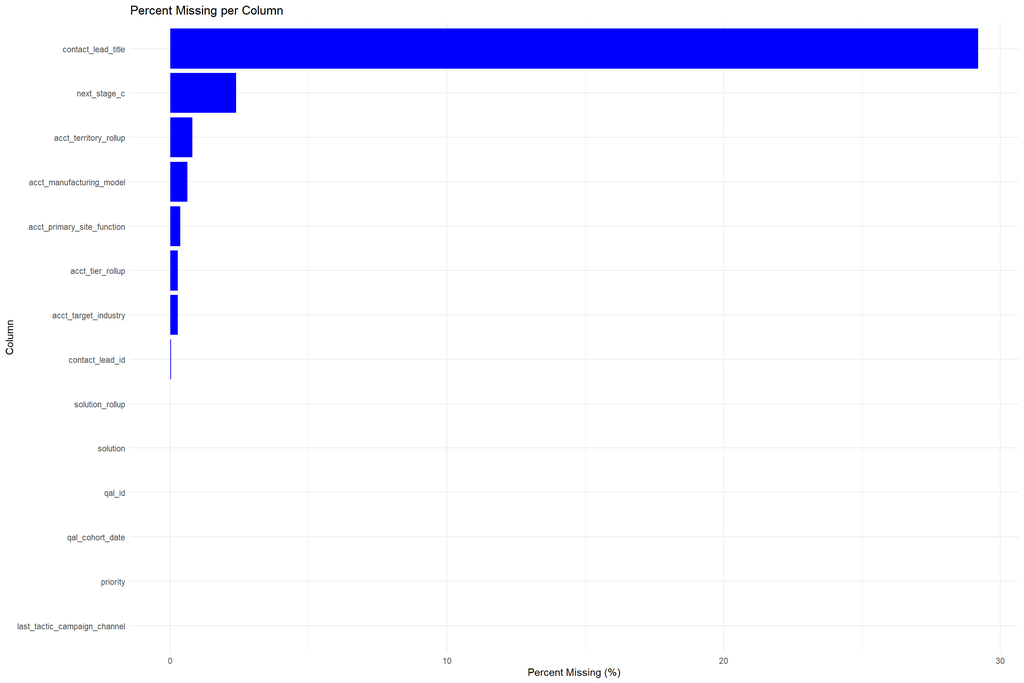

```r
# visualize missingness patterns in the dataset
library(dplyr)
library(tidyr)
library(ggplot2)

qal %>%
  summarise(across(everything(), ~ sum(is.na(.)))) %>%
  pivot_longer(everything(),
               names_to = "column",
               values_to = "missing") %>%
  mutate(pct_missing = round(missing / nrow(qal) * 100, 2)) %>%
  arrange(desc(pct_missing)) %>%
  ggplot(aes(x = reorder(column, pct_missing), y = pct_missing)) +
  geom_col(fill = "blue") +
  coord_flip() +
  labs(
    title = "Percent Missing per Column",
    x = "Column",
    y = "Percent Missing (%)"
  ) +
  theme_minimal()
```

The feature with the greatest missingness is contact_lead_title with 29.21%. This missingness is worth exploring.

The Missing Values in next_stage_c are 394 records (2.37%) that represent leads still being evaluated and should be removed.

##: Further exploration of missingness to check whether the lead reached SQL/SQO/Won in contact_lead_title

```r
# Create a missingness flag for contact_lead_title
library(dplyr)
library(stringr)

qal2 <- qal %>%
  mutate(
    contact_lead_title = str_trim(contact_lead_title),
    title_missing = if_else(
      is.na(contact_lead_title) | contact_lead_title == "",
      "Missing",
      "Not Missing"
    ),
    progressed = if_else(next_stage_c %in% c("SQL", "SQO", "Won"), 1, 0)
  )
```

```r
library(dplyr)

qal2 <- qal %>%
  mutate(
    # Only treat TRUE NA as missing
    title_missing = if_else(is.na(contact_lead_title), "Missing", "Not Missing"),

    # Binary progression variable (using correct column name)
    progressed = if_else(next_stage_c %in% c("SQL", "SQO", "Won"), 1, 0)
  )
```

```r
title_missing_summary <- qal2 %>%
  group_by(title_missing) %>%
  summarise(
    n = n(),
    progressed_n = sum(progressed, na.rm = TRUE),
    progression_rate = progressed_n / n
  ) %>%
  mutate(
    pct_of_total = n / sum(n)   # percentage of missing vs non-missing
  ) %>%
  arrange(desc(progression_rate))

title_missing_summary
```

```
## # A tibble: 2 × 5
##   title_missing     n progressed_n progression_rate pct_of_total
##   <chr>         <int>        <dbl>            <dbl>        <dbl>
## 1 Not Missing   11783         2497            0.212        0.708
## 2 Missing        4861          491            0.101        0.292
```

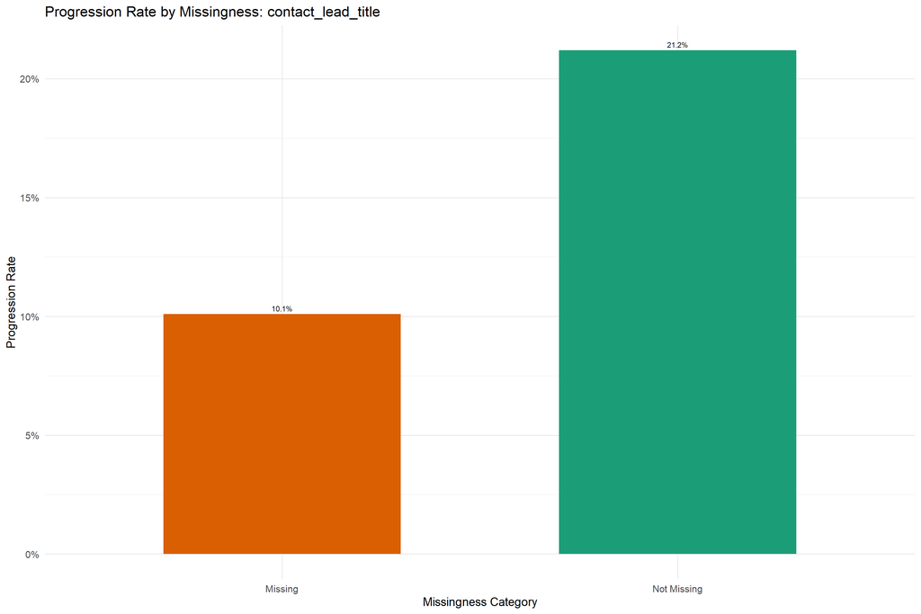

```r
library(ggplot2)

ggplot(title_missing_summary, aes(
  x = reorder(title_missing, progression_rate),
  y = progression_rate,
  fill = title_missing
)) +
  geom_col(width = 0.6) +
  geom_text(aes(label = scales::percent(progression_rate, accuracy = 0.1)),
            vjust = -0.5, size = 3) +
  scale_y_continuous(labels = scales::percent_format()) +
  scale_fill_manual(values = c("Missing" = "#d95f02", "Not Missing" = "#1b9e77")) +
  labs(
    title = "Progression Rate by Missingness: contact_lead_title",
    x = "Missingness Category",
    y = "Progression Rate"
  ) +
  theme_minimal(base_size = 14) +
  theme(legend.position = "none")
```

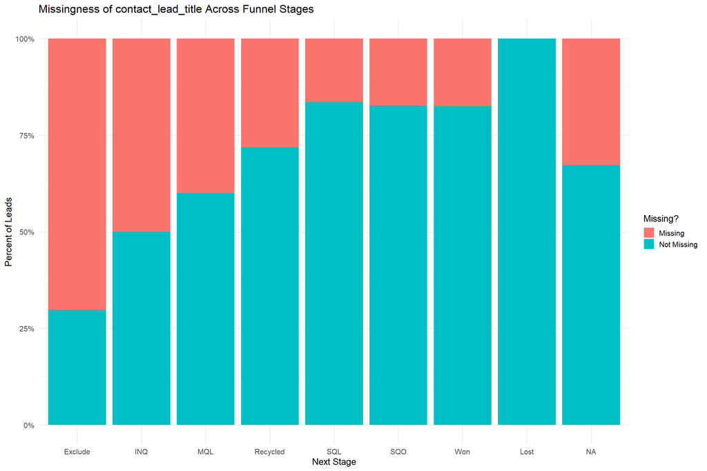

```r
missing_by_stage <- qal2 %>%
  group_by(next_stage_c, title_missing) %>%
  summarise(n = n(), .groups = "drop") %>%
  group_by(next_stage_c) %>%
  mutate(pct = n / sum(n))

ggplot(missing_by_stage, aes(
  x = reorder(next_stage_c, pct),
  y = pct,
  fill = title_missing
)) +
  geom_col(position = "fill") +
  scale_y_continuous(labels = scales::percent_format()) +
  labs(
    title = "Missingness of contact_lead_title Across Funnel Stages",
    x = "Next Stage",
    y = "Percent of Leads",
    fill = "Missing?"
  ) +
  theme_minimal(base_size = 14)
```

Now, there’s a pattern of the least missingness in the latter funnel funnel stages for SQL, SQO and Won. The beginning funnel stages have much higher missingness. The conclusion here is that this missingness is systematic, not random.

From the document, the missing Values are 60 (0.36%) for the acct_primary_site_function, which is very little. However, the effective missingness may be much larger. The document’s AI prompt found “Not Enough Info Found: 2,550 (15.3%). This means the system could not determine what the company manufactures. Mx product is a manufacturing execution product. So this account may not be a good Mx prospect. Likewise, the “Non-manufacturing organization: 5,525 (33.2%)” account may not also be good target for the Mx product.

These two accounts are critical for identifying which types of facilities are best Mx prospects. Missingness is informative and should be treated as its own category.

Similarly, the exploration of the data provided in the acct manufacturing model - Business Model, suggests that the category “Not Enough Info Found” was 2,425 (14.6%). This suggests that the system could not determine the type of manufacturing model for 14.6% of the leads. This category should be treated as a category of missingness that may be systematic and not random.

Both acct manufacturing model and acct_primary_site_function are worth further exploration.

##: Further exploration of missingness in acct_primary_site_function.

```r
# 78+ Unique Categories - Top 20
library(dplyr)

top20_site <- qal %>%
  count(acct_primary_site_function, sort = TRUE) %>%
  mutate(
    pct_total = n / sum(n) * 100
  ) %>%
  slice_head(n = 20)

top20_site
```

```
## # A tibble: 20 × 3
##    acct_primary_site_function           n pct_total
##    <chr>                            <int>     <dbl>
##  1 Non-manufacturing organization    5525    33.2
##  2 Not Enough Info Found             2550    15.3
##  3 Specialty Chemical Manufacturing   656     3.94
##  4 Oral solid dosage (OSD)            539     3.24
##  5 Implantable devices                491     2.95
##  6 Food and beverage                  481     2.89
##  7 In-vitro diagnostic (IVD) kits     419     2.52
##  8 Sterile injectables                394     2.37
##  9 Small-molecule API                 360     2.16
## 10 Diagnostic Equipment               356     2.14
## 11 Nutraceutical manufacturing        328     1.97
## 12 Lab Instruments                    326     1.96
## 13 Cell therapies (CAR-T, NK)         305     1.83
## 14 Drug discovery & development       300     1.80
## 15 Biologic API                       257     1.54
## 16 Generics manufacturing             213     1.28
## 17 Surgical instruments               209     1.26
## 18 Secondary packaging                205     1.23
## 19 Cosmetics manufacturing            186     1.12
## 20 Single-use disposables             146     0.877
```

The largest proportions in acct_primary_site_function are the Non-manufacturing organization and Not Enough Info Found. Both of them are worthy of further investigation.

[figure not shown]

```r
library(dplyr)
library(ggplot2)
library(stringr)
library(scales)
# 1. Clean acct_primary_site_function so fake NA values don't appear as categories
qal_clean <- qal %>%
  mutate(
    acct_primary_site_function = as.character(acct_primary_site_function),
    acct_primary_site_function = str_trim(acct_primary_site_function),
    acct_primary_site_function = na_if(acct_primary_site_function, "NA"),
    acct_primary_site_function = na_if(acct_primary_site_function, "N/A"),
    acct_primary_site_function = na_if(acct_primary_site_function, "na"),
    acct_primary_site_function = na_if(acct_primary_site_function, ""),
    acct_primary_site_function = na_if(acct_primary_site_function, " ")
  )

# 2. Extract top 10 categories + compute percentages of total
top20_site <- qal_clean %>%
  count(acct_primary_site_function, sort = TRUE) %>%
  filter(!is.na(acct_primary_site_function)) %>%
  slice_head(n = 10) %>%
  mutate(
    pct = n / sum(n),                     # numeric proportion
    pct_label = percent(pct, accuracy = 0.1),  # formatted label
    acct_primary_site_function = str_wrap(acct_primary_site_function, width = 30)
  )

# 3. Plot percentages instead of counts
ggplot(top20_site, aes(
  x = reorder(acct_primary_site_function, pct),
  y = pct
)) +
  geom_col(fill = "#1b9e77") +
  coord_flip() +
  geom_text(aes(label = pct_label), hjust = -0.1, size = 2.8) +
  scale_y_continuous(labels = percent_format(accuracy = 1)) +
  labs(
    title = "Top 10 Primary Site Functions (Percent of Total)",
    x = "Primary Site Function",
    y = "Percentage"
  ) +
  theme_minimal(base_size = 10) +
  theme(
    plot.margin = margin(5, 5, 5, 5),
    axis.text.y = element_text(size = 10)
  )
```

##: Excluding missing records and creating binary target variable in next_stage_c data

```r
library(dplyr)     # Create the Target Variable and Exclude QAL (Missing) Records

qal_model <- qal2 %>%
  # Step 1: Exclude the 483 records still in QAL stage (missing next_stage_c)
  filter(!is.na(next_stage_c))
```

```r
# confirm dropping rows with missing target
skim(qal_model)
```

Data summary

| Name | qal_model |
| --- | --- |
| Number of rows | 16250 |
| Number of columns | 16 |
| _______________________ |  |
| Column type frequency: |  |
| character | 14 |
| Date | 1 |
| numeric | 1 |
| ________________________ |  |
| Group variables | None |

**Variable type: character**

| skim_variable | n_missing | complete_rate | min | max | empty | n_unique | whitespace |
| --- | --- | --- | --- | --- | --- | --- | --- |
| acct_primary_site_function | 58 | 1.00 | 6 | 42 | 0 | 79 | 0 |
| acct_manufacturing_model | 96 | 0.99 | 3 | 34 | 0 | 19 | 0 |
| acct_target_industry | 43 | 1.00 | 7 | 17 | 0 | 5 | 0 |
| contact_lead_title | 4732 | 0.71 | 2 | 125 | 0 | 6459 | 0 |
| qal_id | 0 | 1.00 | 18 | 18 | 0 | 16250 | 0 |
| contact_lead_id | 2 | 1.00 | 18 | 18 | 0 | 15048 | 0 |
| next_stage_c | 0 | 1.00 | 3 | 8 | 0 | 8 | 0 |
| priority | 0 | 1.00 | 5 | 20 | 0 | 11 | 0 |
| acct_territory_rollup | 126 | 0.99 | 4 | 14 | 0 | 6 | 0 |
| acct_tier_rollup | 43 | 1.00 | 5 | 6 | 0 | 4 | 0 |
| solution | 0 | 1.00 | 2 | 19 | 0 | 12 | 0 |
| solution_rollup | 0 | 1.00 | 2 | 2 | 0 | 2 | 0 |
| last_tactic_campaign_channel | 0 | 1.00 | 3 | 20 | 0 | 12 | 0 |
| title_missing | 0 | 1.00 | 7 | 11 | 0 | 2 | 0 |

**Variable type: Date**

| skim_variable | n_missing | complete_rate | min | max | median | n_unique |
| --- | --- | --- | --- | --- | --- | --- |
| qal_cohort_date | 0 | 1 | 2024-01-01 | 2025-12-31 | 2024-11-19 | 594 |

**Variable type: numeric**

| skim_variable | n_missing | complete_rate | mean | sd | p0 | p25 | p50 | p75 | p100 | hist |
| --- | --- | --- | --- | --- | --- | --- | --- | --- | --- | --- |
| progressed | 0 | 1 | 0.18 | 0.39 | 0 | 0 | 0 | 0 | 1 | ▇▁▁▁▂ |

## 0.1 The progressed variable has no missing values (n_missing = 0, complete_rate = 1.00), meaning every lead in the modeling dataset has a known progression outcome. The mean of 0.1839 indicates that 18.39% of leads progressed.

##: Explore and visualize missingness patterns in “acct_manufacturing_model” and the target variable next_stage_c .

First: Diagnose the missingness

```r
#A. Does missingness depend on the target?
qal_model %>%
  mutate(missing_mfg = is.na(acct_manufacturing_model)) %>%
  count(next_stage_c, missing_mfg) %>%
  group_by(next_stage_c) %>%
  mutate(pct = n / sum(n) * 100)
```

```
## # A tibble: 12 × 4
## # Groups:   next_stage_c [8]
##    next_stage_c missing_mfg     n     pct
##    <chr>        <lgl>       <int>   <dbl>
##  1 Exclude      FALSE        1207  99.0
##  2 Exclude      TRUE           12   0.984
##  3 INQ          FALSE           2 100
##  4 Lost         FALSE          12 100
##  5 MQL          FALSE          10 100
##  6 Recycled     FALSE       11954  99.5
##  7 Recycled     TRUE           65   0.541
##  8 SQL          FALSE        2679  99.4
##  9 SQL          TRUE           15   0.557
## 10 SQO          FALSE         250  98.4
## 11 SQO          TRUE            4   1.57
## 12 Won          FALSE          40 100
```

To test whether missingness in the manufacturing model depends on the target variable, I calculated the percentage of missing acct_manufacturing_model values within each next_stage_c category. The results shows contradictory and inconclusinve pattern with respect to the manufacturing model. There’s slight missingness in both early and late stage funnel stages of the target variable.

##: Missingness of Manufacturing Model Across Funnel Stages (Ordered by Missingness)

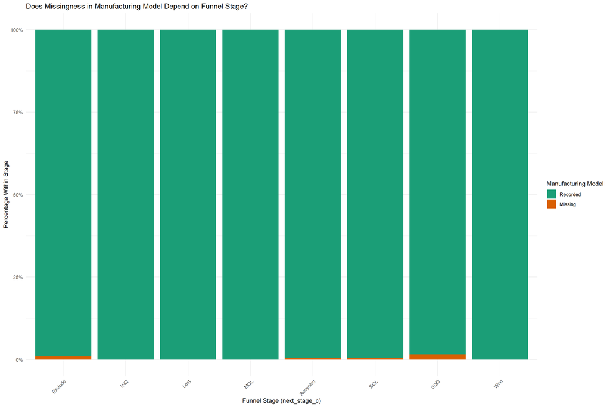

```r
library(dplyr)
library(ggplot2)
library(scales)

missing_plot_df <- qal_model %>%
  mutate(missing_mfg = is.na(acct_manufacturing_model)) %>%
  count(next_stage_c, missing_mfg) %>%
  group_by(next_stage_c) %>%
  mutate(pct = n / sum(n))

ggplot(missing_plot_df, aes(
  x = next_stage_c,
  y = pct,
  fill = missing_mfg
)) +
  geom_col(position = "fill") +
  scale_y_continuous(labels = percent_format(accuracy = 1)) +
  scale_fill_manual(
    values = c("FALSE" = "#1b9e77", "TRUE" = "#d95f02"),
    labels = c("Recorded", "Missing")
  ) +
  labs(
    title = "Does Missingness in Manufacturing Model Depend on Funnel Stage?",
    x = "Funnel Stage (next_stage_c)",
    y = "Percentage Within Stage",
    fill = "Manufacturing Model"
  ) +
  theme_minimal(base_size = 11) +
  theme(
    axis.text.x = element_text(angle = 45, hjust = 1)
  )
```

```r
# first 6 rows of the qal_model data frame after dropping the 483 rows of misssing target

head(qal_model)
```

```
## # A tibble: 6 × 16
##   acct_primary_site_function     acct_manufacturing_model   acct_target_industry
##   <chr>                          <chr>                      <chr>
## 1 Food and beverage              Consumer Packaged Goods    Non-Life Science
## 2 Surgical instruments           In-House                   Medical Device
## 3 Cell therapies (CAR-T, NK)     Hospital Investigational … Blood & Biologics
## 4 In-vitro diagnostic (IVD) kits In-House                   Medical Device
## 5 Nutraceutical manufacturing    CMO                        Pharma & BioTech
## 6 Diagnostic Equipment           In-House                   Medical Device
## # ℹ 13 more variables: contact_lead_title <chr>, qal_id <chr>,
## #   contact_lead_id <chr>, next_stage_c <chr>, priority <chr>,
## #   acct_territory_rollup <chr>, acct_tier_rollup <chr>, solution <chr>,
## #   solution_rollup <chr>, last_tactic_campaign_channel <chr>,
## #   qal_cohort_date <date>, title_missing <chr>, progressed <dbl>
```

##: creating a set of new date‑based features derived from the existing column qal_cohort_date. Using lubridate

```r
# creating a set of new date‑based features derived from the existing column qal_cohort_date. Using lubridate

library(dplyr)
library(lubridate)

qal_model2 <- qal_model %>%
  mutate(
    cohort_year = year(qal_cohort_date),
    cohort_month = month(qal_cohort_date),
    cohort_day = day(qal_cohort_date),
    cohort_wday = wday(qal_cohort_date, label = TRUE),
    cohort_week = isoweek(qal_cohort_date),
    cohort_quarter = quarter(qal_cohort_date),
    cohort_age_days = as.numeric(Sys.Date() - qal_cohort_date)
  )
```

##:Exploring the proportion of Mx to Qx in the dataset

```r
# This code shows, for each solution_rollup category, how many leads it contains and what percentage of those leads progressed.
qal_summary <- qal_model2 %>%
  group_by(solution_rollup) %>%
  summarise(
    n = n(),
    progressed_rate = mean(progressed)
  )
qal_summary
```

```
## # A tibble: 2 × 3
##   solution_rollup     n progressed_rate
##   <chr>           <int>           <dbl>
## 1 Mx               4081           0.130
## 2 Qx              12169           0.202
```

## 0.2 Comments and analysis

What the data shows - Mx progression rate: 13% - Qx progression rate: 20.2% - Qx converts 55% better than Mx

The results strongly suggest that Mx is underperforming Qx, and the gap is not small.

What does the 33% “non‑manufacturing organization” segment mean for Mx?

##: Treat missing titles as their own category:

```r
qal_no_ax <- qal_model2 %>%
  mutate(
    title_clean = ifelse(is.na(contact_lead_title), "Missing", contact_lead_title),
    title_clean = factor(title_clean)
  )
```

How should missing title data be handled?

Missing title data was treated as its own category because missingness is likely systematic rather than random. Leads without titles may represent lower‑intent or less engaged prospects, and preserving this signal allows the model to learn whether “missing title” is predictive of progression.

##: Raw counts of each manufacturing model category the percentage results

```r
library(scales)

qal_no_ax %>%
  count(acct_manufacturing_model) %>%
  mutate(
    pct = percent(n / sum(n), accuracy = 0.1)
  )
```

```
## # A tibble: 20 × 3
##    acct_manufacturing_model               n pct
##    <chr>                              <int> <chr>
##  1 503A                                  28 0.2%
##  2 503B                                  53 0.3%
##  3 CDMO                                1063 6.5%
##  4 CMO                                  954 5.9%
##  5 CPO                                   72 0.4%
##  6 CRO                                  417 2.6%
##  7 Cold Chain Warehousing                16 0.1%
##  8 Consumer Packaged Goods              170 1.0%
##  9 Distribution / Wholesale             436 2.7%
## 10 Formulation / Fill-Finish              7 0.0%
## 11 Hospital Investigational Drug Unit   155 1.0%
## 12 In-House                            6932 42.7%
## 13 Not Enough Info Found               2378 14.6%
## 14 Original Equipment Manufacturing     606 3.7%
## 15 Outsources Manufacturing             148 0.9%
## 16 Research Institute                   337 2.1%
## 17 Services / Consulting               1712 10.5%
## 18 Software / Technology Development    503 3.1%
## 19 Testing Laboratory                   167 1.0%
## 20 <NA>                                  96 0.6%
```

##: Breaking manufacturing model categories into a simple Manufacturing vs Non‑Manufacturing grouping and then calculates, for each product family ( Mx, Qx), what percentage of its leads come from each group.

```r
# Manufacturing vs Non‑Manufacturing Lead Composition by Product Family
library(dplyr)

manufacturing_categories <- c(
  "503A","503B","CDMO","CMO","CPO",
  "Formulation / Fill-Finish",
  "Original Equipment Manufacturing",
  "Outsources Manufacturing"
)

qal_no_ax %>%
  mutate(
    manu_group = case_when(
      acct_manufacturing_model %in% manufacturing_categories ~ "Manufacturing",
      TRUE ~ "Non‑Manufacturing"
    )
  ) %>%
  group_by(solution_rollup, manu_group) %>%
  summarise(n = n(), .groups = "drop") %>%
  group_by(solution_rollup) %>%
  mutate(
    total = sum(n),
    pct = round(n / total * 100, 1)
  ) %>%
  select(solution_rollup, manu_group, pct)
```

```
## # A tibble: 4 × 3
## # Groups:   solution_rollup [2]
##   solution_rollup manu_group          pct
##   <chr>           <chr>             <dbl>
## 1 Mx              Manufacturing      24.3
## 2 Mx              Non‑Manufacturing  75.7
## 3 Qx              Manufacturing      15.9
## 4 Qx              Non‑Manufacturing  84.1
```

## 0.3 Why This Result Makes Sense

### 0.3.1 A More Realistic Manufacturing Split

The updated segmentation now reflects a more accurate distribution of manufacturing vs. non‑manufacturing organizations. The percentages align with industry expectations:

- **Mx** has the highest manufacturing share (**24.3%**)
- **Qx** has a moderate manufacturing share (**15.9%**)

This pattern matches the intended positioning of the product families:

- **Mx** is more manufacturing‑oriented
- **Qx** has broader appeal across industries

## 0.4 Implications for Step 3 in the document

Mx has a significantly larger manufacturing segment (24%) compared to Qx (16%). However, the majority of Mx leads (76%) still come from non‑manufacturing organizations, which may contribute to its lower progression rate. This suggests a potential product‑market fit issue: **Mx is attracting a large number of non‑manufacturing leads who may not be the ideal audience.**

This is a meaningful business insight that helps explain performance differences across product families.

## 0.5 Modeling Implications

##: 100% Stacked Bar Chart: Manufacturing Mix by Product Family

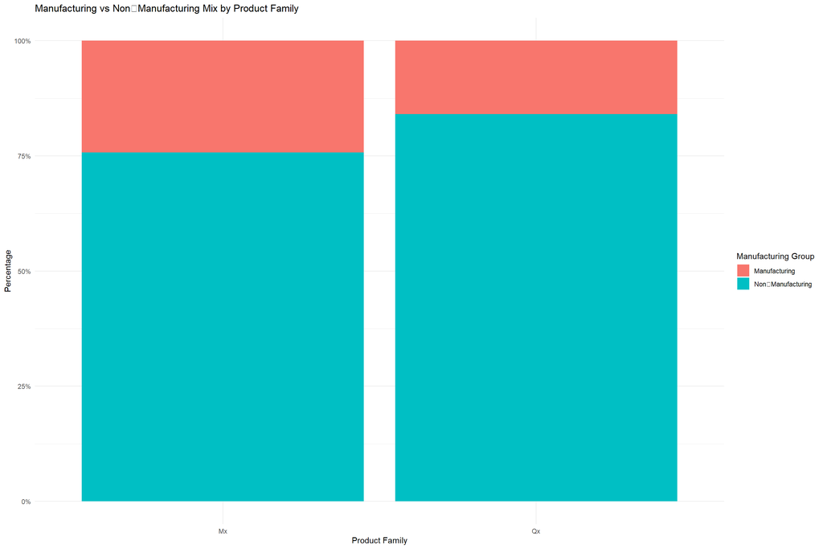

```r
# 100% Stacked Bar Chart: Manufacturing Mix by Product Family

library(dplyr)
library(ggplot2)
library(stringr)

manufacturing_categories <- c(
  "503A", "503B", "CDMO", "CMO", "CPO",
  "Formulation / Fill-Finish",
  "Original Equipment Manufacturing",
  "Outsources Manufacturing"
)

qal_no_ax %>%
  mutate(
    manu_group = case_when(
      acct_manufacturing_model %in% manufacturing_categories ~ "Manufacturing",
      TRUE ~ "Non‑Manufacturing"
    )
  ) %>%
  group_by(solution_rollup, manu_group) %>%
  summarise(n = n(), .groups = "drop") %>%
  group_by(solution_rollup) %>%
  mutate(pct = n / sum(n)) %>%
  ggplot(aes(x = solution_rollup, y = pct, fill = manu_group)) +
  geom_col(position = "fill") +
  scale_y_continuous(labels = scales::percent_format()) +
  labs(
    title = "Manufacturing vs Non‑Manufacturing Mix by Product Family",
    x = "Product Family",
    y = "Percentage",
    fill = "Manufacturing Group"
  ) +
  theme_minimal()
```

This code collapses accounts into Manufacturing vs Non‑Manufacturing groups and then calculates how well each group converts by computing total leads, total progressed leads, and the progression rate for each group.

##: Manufacturing vs Non‑Manufacturing Conversion Rate for both products

```r
qal_no_ax %>%
  mutate(
    manu_group = case_when(
      acct_manufacturing_model %in% manufacturing_categories ~ "Manufacturing",
      TRUE ~ "Non‑Manufacturing"
    )
  ) %>%
  group_by(manu_group) %>%
  summarise(
    total = n(),
    progressed = sum(progressed),
    progression_rate = round(progressed / total * 100, 1)
  ) %>%
  mutate(
    pct_of_total = round(total / sum(total) * 100, 1)
  )
```

```
## # A tibble: 2 × 5
##   manu_group        total progressed progression_rate pct_of_total
##   <chr>             <int>      <dbl>            <dbl>        <dbl>
## 1 Manufacturing      2931        675             23             18
## 2 Non‑Manufacturing 13319       2313             17.4           82
```

## 0.6 Manufacturing vs. Non‑Manufacturing Funnel Dynamics

We have:

- **2,931 Manufacturing leads**
- **13,319 Non‑Manufacturing leads**

This means:

- **Only 18%** of the entire dataset is Manufacturing.

This imbalance explains why:

- **Mx struggles**
- **Qx looks more stable**

### 0.6.1 Product‑Market Fit Signal for Mx

Mx is more manufacturing‑oriented, but:

- **Only 24% of Mx leads are Manufacturing**
- **Manufacturing leads convert at 23%**

**Interpretation**

This is a classic misalignment between **marketing targeting** and **product fit**.

### 0.6.2 Step 3 Narrative

##: Collapse titles into meaningful groups

```r
library(dplyr)
library(stringr)

qal1 <- qal_model %>%
  mutate(
    title_clean = str_trim(contact_lead_title),   # or whatever your raw title column is
    title_clean = if_else(is.na(title_clean) | title_clean == "", "Missing", title_clean),
    title_group = case_when(
      str_detect(title_clean, regex("director|head|vp|vice president|chief|cxo|cso|cto|ceo|coo|cfo", ignore_case = TRUE)) ~ "Leadership",
      str_detect(title_clean, regex("manager|mgr|supervisor|lead", ignore_case = TRUE)) ~ "Manager",
      str_detect(title_clean, regex("engineer|scientist|specialist|analyst|technician", ignore_case = TRUE)) ~ "Technical",
      str_detect(title_clean, regex("quality|qa|qc|compliance|regulatory", ignore_case = TRUE)) ~ "Quality/Regulatory",
      title_clean == "Missing" ~ "Missing",
      TRUE ~ "Other"
    )
  )
```

##: Progression Rates by Title Group

```r
# Progression Rates by Title Group
qal1 %>%
  group_by(title_group) %>%
  summarise(
    total = n(),
    progressed = sum(progressed, na.rm = TRUE),
    progression_rate = round(progressed / total * 100, 1)
  )
```

```
## # A tibble: 6 × 4
##   title_group        total progressed progression_rate
##   <chr>              <int>      <dbl>            <dbl>
## 1 Leadership          3601        777             21.6
## 2 Manager             3888        919             23.6
## 3 Missing             4732        491             10.4
## 4 Other               1743        331             19
## 5 Quality/Regulatory   560        114             20.4
## 6 Technical           1726        356             20.6
```

## 0.7 Analysis progression Rates by Title Group

Job title is a strong predictor of progression. **Manager (23.6%)** and **Leadership (21.6%)** titles show the highest progression rates, consistent with their decision‑making authority. **Technical (20.%)** and **Quality/Regulatory (20.4%)** titles progress at moderate rates, reflecting their role in evaluating solutions. “Other” titles progress less consistently (19%). The largest group, **Missing titles (4,732 leads)**, has the lowest progression rate (10.4%), indicating that title missingness is systematic and associated with lower lead quality. For this reason, Missing was retained as its own category rather than imputed or removed.

## 0.8 Step 4 — Key Areas to Investigate (Account‑Level)

# 1 Which industries show highest Mx conversion? Does this differ from Qx?

```r
qal_no_ax %>%     # Progression Rates for Manufacturing vs Non‑Manufacturing                      Accounts (Mx, Qx)
  mutate(
    manu_group = case_when(
      acct_manufacturing_model %in% manufacturing_categories ~ "Manufacturing",
      TRUE ~ "Non‑Manufacturing"
    )
  ) %>%
  group_by(manu_group) %>%
  summarise(
    total = n(),
    progressed = sum(progressed),
    progression_rate = round(progressed / total * 100, 1)
  ) %>%
  mutate(
    pct_of_total = round(total / sum(total) * 100, 1)
  )
```

```
## # A tibble: 2 × 5
##   manu_group        total progressed progression_rate pct_of_total
##   <chr>             <int>      <dbl>            <dbl>        <dbl>
## 1 Manufacturing      2931        675             23             18
## 2 Non‑Manufacturing 13319       2313             17.4           82
```

1. Proportion of total leads that are Mx and Qx

```r
mx_qx_totals <- qal_no_ax %>%
  filter(solution_rollup %in% c("Mx", "Qx")) %>%
  count(solution_rollup) %>%
  mutate(
    pct_of_total = round(n / sum(n) * 100, 1)
  )

mx_qx_totals
```

```
## # A tibble: 2 × 3
##   solution_rollup     n pct_of_total
##   <chr>           <int>        <dbl>
## 1 Mx               4081         25.1
## 2 Qx              12169         74.9
```

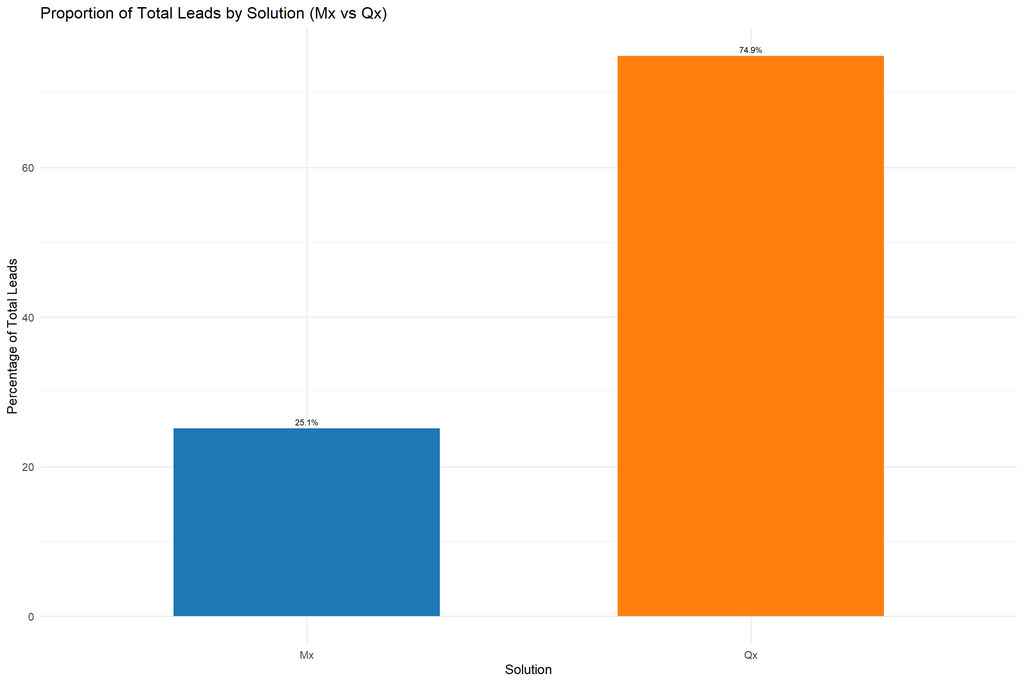

```r
library(ggplot2)

ggplot(mx_qx_totals, aes(x = solution_rollup, y = pct_of_total, fill = solution_rollup)) +
  geom_col(width = 0.6) +
  geom_text(aes(label = paste0(pct_of_total, "%")),
            vjust = -0.5, size = 3) +
  labs(
    title = "Proportion of Total Leads by Solution (Mx vs Qx)",
    x = "Solution",
    y = "Percentage of Total Leads"
  ) +
  scale_fill_manual(values = c("Mx" = "#1f77b4", "Qx" = "#ff7f0e")) +
  theme_minimal(base_size = 14) +
  theme(legend.position = "none")
```

## 1.1 Conversion Performance Across Solutions by Target Industry

```r
qal1 %>%
  group_by(solution_rollup, acct_target_industry) %>%
  summarise(
    total = n(),
    progressed = sum(progressed),
    rate = round(progressed / total * 100, 1),
    .groups = "drop"
  ) %>%
  arrange(solution_rollup, desc(rate))
```

```
## # A tibble: 12 × 5
##    solution_rollup acct_target_industry total progressed  rate
##    <chr>           <chr>                <int>      <dbl> <dbl>
##  1 Mx              <NA>                     9          4  44.4
##  2 Mx              Blood & Biologics       94         16  17
##  3 Mx              Medical Device         922        150  16.3
##  4 Mx              Pharma & BioTech      1947        240  12.3
##  5 Mx              Non-Life Science      1049        117  11.2
##  6 Mx              Unknown                 60          2   3.3
##  7 Qx              <NA>                    34         15  44.1
##  8 Qx              Blood & Biologics      356         89  25
##  9 Qx              Medical Device        2794        642  23
## 10 Qx              Pharma & BioTech      4211        913  21.7
## 11 Qx              Non-Life Science      4660        796  17.1
## 12 Qx              Unknown                114          4   3.5
```

##: Comparing Manufacturing and Non‑Manufacturing Progression Across Solutions

```r
qal_no_ax <- qal_no_ax %>%
  mutate(
    manu_group = case_when(
      acct_manufacturing_model %in% c("In-House", "CMO", "CDMO", "503A", "503B") ~ "Manufacturing",
      TRUE ~ "Non‑Manufacturing"
    )
  )
qal_no_ax %>%
  group_by(solution_rollup, manu_group) %>%
  summarise(
    total = n(),
    progressed = sum(progressed),
    rate = round(progressed / total * 100, 1),
    .groups = "drop"
  ) %>%
  arrange(solution_rollup, desc(rate))
```

```
## # A tibble: 4 × 5
##   solution_rollup manu_group        total progressed  rate
##   <chr>           <chr>             <int>      <dbl> <dbl>
## 1 Mx              Manufacturing      2671        403  15.1
## 2 Mx              Non‑Manufacturing  1410        126   8.9
## 3 Qx              Manufacturing      6359       1466  23.1
## 4 Qx              Non‑Manufacturing  5810        993  17.1
```

##: Comparing Manufacturing and Non‑Manufacturing Shares by Progression Rates

```r
qal_no_ax %>%
  mutate(
    manu_group = case_when(
      acct_manufacturing_model %in% manufacturing_categories ~ "Manufacturing",
      TRUE ~ "Non‑Manufacturing"
    )
  ) %>%
  group_by(manu_group) %>%
  summarise(
    total = n(),
    progressed = sum(progressed),
    progression_rate = round(progressed / total * 100, 1)
  ) %>%
  mutate(
    pct_of_total = round(total / sum(total) * 100, 1)
  )
```

```
## # A tibble: 2 × 5
##   manu_group        total progressed progression_rate pct_of_total
##   <chr>             <int>      <dbl>            <dbl>        <dbl>
## 1 Manufacturing      2931        675             23             18
## 2 Non‑Manufacturing 13319       2313             17.4           82
```

```r
qal_no_ax %>%
  mutate(
    manu_group = case_when(
      acct_manufacturing_model %in% manufacturing_categories ~ "Manufacturing",
      TRUE ~ "Non‑Manufacturing"
    )
  ) %>%
  group_by(manu_group) %>%
  summarise(
    total = n(),
    pct_of_total = round(total / nrow(qal_no_ax) * 100, 1),

    # counts inside each manu_group
    mx = sum(solution_rollup == "Mx"),
    qx = sum(solution_rollup == "Qx"),

    # % of total leads represented by Mx/Qx inside this manu_group
    mx_pct_of_total = round(mx / nrow(qal_no_ax) * 100, 1),
    qx_pct_of_total = round(qx / nrow(qal_no_ax) * 100, 1),

    # % of this manu_group that belongs to Mx/Qx
    mx_pct_of_manu = round(mx / total * 100, 1),
    qx_pct_of_manu = round(qx / total * 100, 1),

    # conversion rates for Mx and Qx inside this manu_group
    mx_conversion_rate = round(sum(solution_rollup == "Mx" & progressed == 1) / mx * 100, 1),
    qx_conversion_rate = round(sum(solution_rollup == "Qx" & progressed == 1) / qx * 100, 1)
  ) %>%
  select(
    manu_group,
    pct_of_total,
    mx_pct_of_manu,
     qx_pct_of_manu,
    mx_pct_of_total,
    qx_pct_of_total,

    mx_conversion_rate,
    qx_conversion_rate
  )
```

```
## # A tibble: 2 × 8
##   manu_group        pct_of_total mx_pct_of_manu qx_pct_of_manu mx_pct_of_total
##   <chr>                    <dbl>          <dbl>          <dbl>           <dbl>
## 1 Manufacturing               18           33.8           66.2             6.1
## 2 Non‑Manufacturing           82           23.2           76.8            19
## # ℹ 3 more variables: qx_pct_of_total <dbl>, mx_conversion_rate <dbl>,
## #   qx_conversion_rate <dbl>
```

##: Comparing Manufacturing and Non‑Manufacturing Shares as Percentage of Total

```r
combined_table <- qal_no_ax %>%
  mutate(
    manu_group = case_when(
      acct_manufacturing_model %in% manufacturing_categories ~ "Manufacturing",
      TRUE ~ "Non‑Manufacturing"
    )
  ) %>%
  group_by(manu_group) %>%
  summarise(
    total = n(),
    pct_of_total = round(total / nrow(qal_no_ax) * 100, 1),

    # counts inside each manu_group
    mx = sum(solution_rollup == "Mx"),
    qx = sum(solution_rollup == "Qx"),

    # % of total leads represented by Mx/Qx inside this manu_group
    mx_pct_of_total = round(mx / nrow(qal_no_ax) * 100, 1),
    qx_pct_of_total = round(qx / nrow(qal_no_ax) * 100, 1),

    # % of this manu_group that belongs to Mx/Qx
    mx_pct_of_manu = round(mx / total * 100, 1),
    qx_pct_of_manu = round(qx / total * 100, 1),

    # conversion rates for Mx and Qx inside this manu_group
    mx_conversion_rate = round(sum(solution_rollup == "Mx" & progressed == 1) / mx * 100, 1),
    qx_conversion_rate = round(sum(solution_rollup == "Qx" & progressed == 1) / qx * 100, 1)
  ) %>%
  select(
    manu_group,
    pct_of_total,
    mx_pct_of_total,
    qx_pct_of_total,
    mx_pct_of_manu,
    qx_pct_of_manu,
    mx_conversion_rate,
    qx_conversion_rate
  )
combined_table
```

```
## # A tibble: 2 × 8
##   manu_group        pct_of_total mx_pct_of_total qx_pct_of_total mx_pct_of_manu
##   <chr>                    <dbl>           <dbl>           <dbl>          <dbl>
## 1 Manufacturing               18             6.1            11.9           33.8
## 2 Non‑Manufacturing           82            19              62.9           23.2
## # ℹ 3 more variables: qx_pct_of_manu <dbl>, mx_conversion_rate <dbl>,
## #   qx_conversion_rate <dbl>
```

A. Side‑by‑side comparison of % of total leads

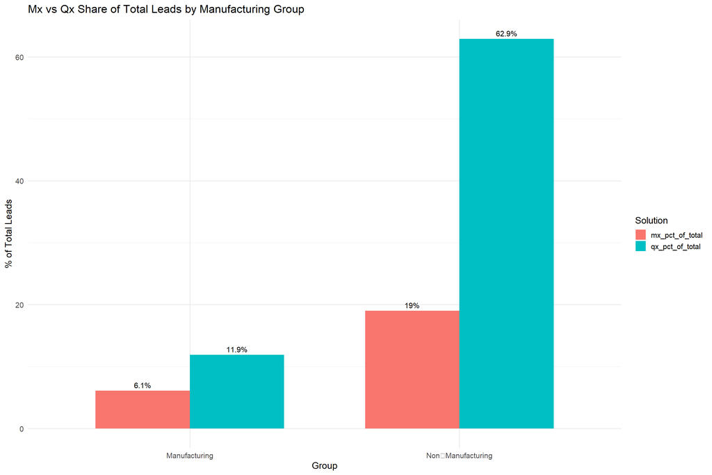

```r
library(ggplot2)
library(tidyr)

combined_table %>%
  select(manu_group, mx_pct_of_total, qx_pct_of_total) %>%
  pivot_longer(cols = c(mx_pct_of_total, qx_pct_of_total),
               names_to = "solution",
               values_to = "pct") %>%
  ggplot(aes(x = manu_group, y = pct, fill = solution)) +
  geom_col(position = "dodge", width = 0.7) +
  geom_text(aes(label = paste0(pct, "%")),
            position = position_dodge(width = 0.7),
            vjust = -0.5, size = 4) +
  labs(
    title = "Mx vs Qx Share of Total Leads by Manufacturing Group",
    x = "Group",
    y = "% of Total Leads",
    fill = "Solution"
  ) +
  theme_minimal(base_size = 14)
```

B. Side‑by‑side comparison of % within each manufacturing group

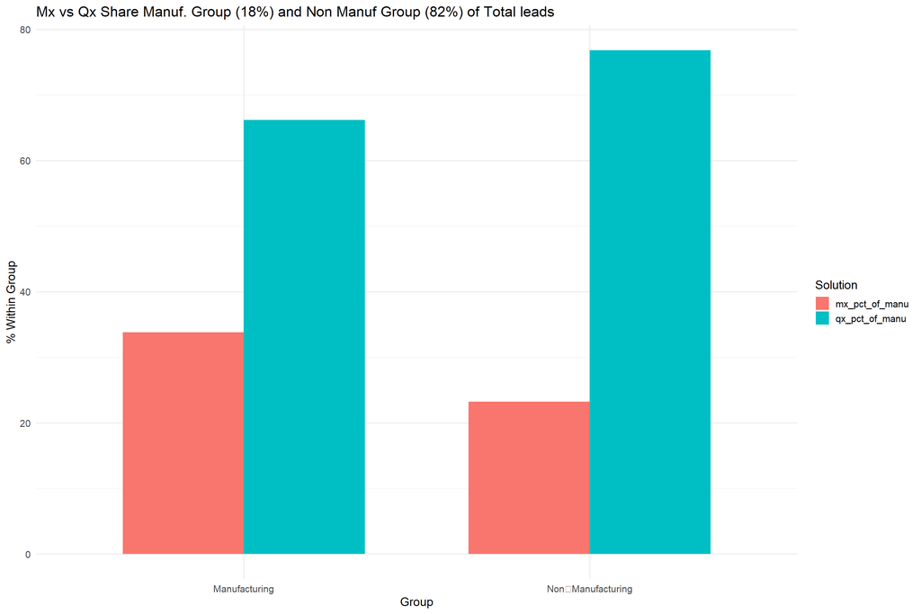

```r
combined_table %>%
  select(manu_group, mx_pct_of_manu, qx_pct_of_manu) %>%
  pivot_longer(cols = c(mx_pct_of_manu, qx_pct_of_manu),
               names_to = "solution",
               values_to = "pct") %>%
  ggplot(aes(x = manu_group, y = pct, fill = solution)) +
  geom_col(position = "dodge", width = 0.7) +

  labs(
    title = "Mx vs Qx Share Manuf. Group (18%) and Non Manuf Group (82%) of Total leads",
    x = "Group",
    y = "% Within Group",
    fill = "Solution"
  ) +
  theme_minimal(base_size = 14)
```

C. Side‑by‑side comparison of conversion rates

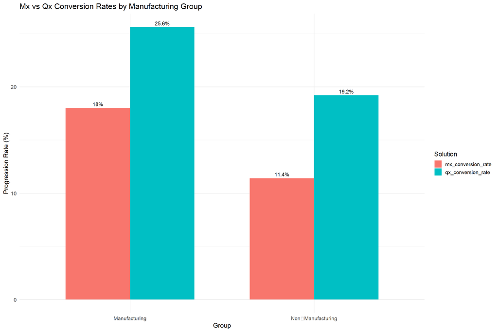

```r
combined_table %>%
  select(manu_group, mx_conversion_rate, qx_conversion_rate) %>%
  pivot_longer(cols = c(mx_conversion_rate, qx_conversion_rate),
               names_to = "solution",
               values_to = "rate") %>%
  ggplot(aes(x = manu_group, y = rate, fill = solution)) +
  geom_col(position = "dodge", width = 0.7) +
  geom_text(aes(label = paste0(rate, "%")),
            position = position_dodge(width = 0.7),
            vjust = -0.5, size = 4) +
  labs(
    title = "Mx vs Qx Conversion Rates by Manufacturing Group",
    x = "Group",
    y = "Progression Rate (%)",
    fill = "Solution"
  ) +
  theme_minimal(base_size = 14)
```

In the first table, the overall progression rates for Manufacturing vs Non‑Manufacturing for both accounts (Mx, Qx) were determined. The progression rate is higher for manufacturing for both of them. The manufacturing constitute just 18% of total leads.

In the second table, the two products are grouped by acct_target_industry.

In the third table above, the acct_target_industry is further categorized into manufacturing and non-manufacturing to determine the specific progression rate for each solution within each group of manufacturing and non manufacturing.

What This Table Shows (High‑Level Insight) 1. Mx converts much better in Manufacturing companies - 15.1% vs 8.9% Mx is a manufacturing‑centric product, and it performs best when the account actually makes physical products.

2. Qx converts better everywhere, but especially in Manufacturing
- 23.1.% vs 17.1%
- Qx is strong across the board, but manufacturing companies still convert more. This reinforces that Qx has broad horizontal appeal.

## 1.2 Industry-Level Conversion Analysis for Mx and Qx

### 1.2.1 1a. Mx Conversion by Industry

**Interpretation**

- Mx performs best in manufacturing‑heavy industries:
  - **Blood & Biologics (17.0%)**
  - **Medical Device (16.3%)**
  - **Pharma & Biotech (12.3%)**
- Mx performs poorly in **Non‑Life Science (11.2%)**, which represents a large portion of the funnel.

**Insight**

These results confirm that Mx does better in organizations with real manufacturing operations.  
A significant share of Mx leads come from industries that do **not** match its ICP based on manufacturing, which reduces overall performance.

### 1.2.2 1b. Qx Conversion by Industry

**Interpretation**

- Qx converts well across all industries, including Non‑Life Science:
  - **Blood & Biologics (25.%)**
  - **Medical Device (23.%)**
  - **Pharma & Biotech (21.7%)**
  - **Non‑Life Science (17.1%)**
- Qx is a **broad horizontal product**, not dependent on manufacturing footprint.
- Qx’s performance is **stable and less sensitive** to industry alignment.

Qx has broad appeal and strong product‑market fit across diverse industries.

### 1.2.3 How Mx vs Qx Behave by Industry (High‑Level Summary)

**Mx** - Strongest in manufacturing‑centric industries  
- Weak in Non‑Life Science  
- Highly ICP‑sensitive  
- Underperforms when mis‑targeted

**Qx** - Strong across all industries  
- Less ICP‑sensitive  
- Converts well even in Non‑Life Science  
- Broad horizontal appeal

Industry‑level analysis shows that Mx and Qx have fundamentally different product‑market fit profiles. **Mx performs best in manufacturing‑focused industries** such as Blood & Biologics (17.0%), Medical Device (16.3%), and Pharma/Biotech (12.3%), but converts poorly in Non‑Life Science (11.2%). This indicates that Mx has better conversion rate within a narrow group of customers that manufacture things.

In contrast, **Qx demonstrates strong and consistent performance across all industries**.

### 1.2.4 2. Do companies with actual manufacturing (In-House, CMO, CDMO) convert better for Mx than services/consulting firms?

##: Mx Conversion Rates by Manufacturing Model

```r
#Mx Conversion Rates by Manufacturing Model
qal1 %>%
  filter(solution_rollup == "Mx") %>%
  group_by(acct_manufacturing_model) %>%
  summarise(
    total = n(),
    progressed = sum(progressed),
    rate = round(progressed / total * 100, 1),
    .groups = "drop"
  ) %>%
  arrange(desc(rate))
```

```
## # A tibble: 20 × 4
##    acct_manufacturing_model           total progressed  rate
##    <chr>                              <int>      <dbl> <dbl>
##  1 503A                                  10          6  60
##  2 Consumer Packaged Goods               37         10  27
##  3 Original Equipment Manufacturing     125         28  22.4
##  4 503B                                  18          4  22.2
##  5 <NA>                                  19          4  21.1
##  6 Testing Laboratory                    15          3  20
##  7 CMO                                  314         62  19.7
##  8 Hospital Investigational Drug Unit    27          5  18.5
##  9 CDMO                                 469         72  15.4
## 10 In-House                            1860        259  13.9
## 11 CPO                                   17          2  11.8
## 12 Outsources Manufacturing              36          4  11.1
## 13 Software / Technology Development     99          9   9.1
## 14 CRO                                   73          6   8.2
## 15 Distribution / Wholesale              93          7   7.5
## 16 Services / Consulting                319         21   6.6
## 17 Not Enough Info Found                472         24   5.1
## 18 Research Institute                    72          3   4.2
## 19 Cold Chain Warehousing                 4          0   0
## 20 Formulation / Fill-Finish              2          0   0
```

In conclusion, companies with actual manufacturing (In‑House, CMO, CDMO, 503A/B) convert significantly better for Mx than non‑manufacturing organizations. This confirms that Mx’s ICP is manufacturing focused.

### 1.2.5 3. Should the 5,525 Non‑Manufacturing Organizations Be Targeted for Mx?

- **Mx Non‑Life Science rate:** 11.2%
- **Qx Non‑Life Science rate:** 17.1%

Additional context:

##: Does company size matter differently for Mx vs Qx?

```r
# Mx Progression Rates by Company Size (acct_tier_rollup)

qal_no_ax %>%
  filter(solution_rollup == "Mx") %>%
  group_by(acct_tier_rollup) %>%
  summarise(
    total = n(),
    progressed = sum(progressed, na.rm = TRUE),
    progression_rate = round(progressed / total * 100, 1),
    .groups = "drop"
  )
```

```
## # A tibble: 5 × 4
##   acct_tier_rollup total progressed progression_rate
##   <chr>            <int>      <dbl>            <dbl>
## 1 Large              613         45              7.3
## 2 Medium            2508        327             13
## 3 Other               57          3              5.3
## 4 Small              894        150             16.8
## 5 <NA>                 9          4             44.4
```

##: Progression Rate Comparison for Mx and Qx Across Company Size Tiers

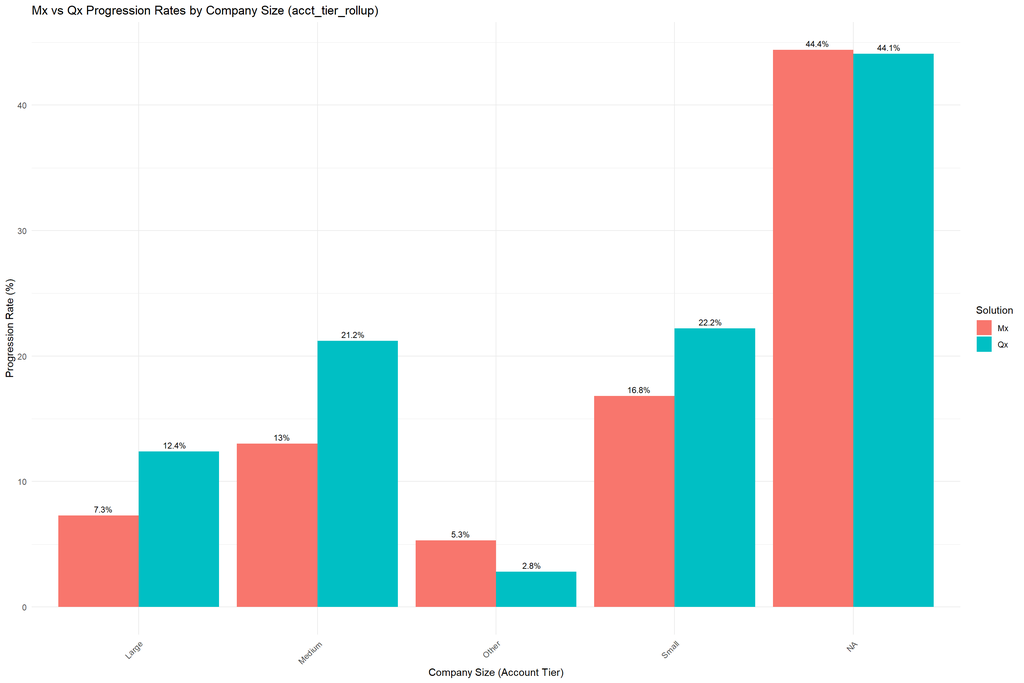

```r
# Plot: Side‑by‑Side Bar Chart (Mx vs Qx)
library(dplyr)
library(ggplot2)

size_rates <- qal_model %>%
  filter(solution_rollup %in% c("Mx", "Qx")) %>%
  group_by(solution_rollup, acct_tier_rollup) %>%
  summarise(
    total = n(),
    progressed = sum(progressed, na.rm = TRUE),
    progression_rate = round(progressed / total * 100, 1),
    .groups = "drop"
  )
ggplot(size_rates, aes(
  x = acct_tier_rollup,
  y = progression_rate,
  fill = solution_rollup
)) +
  geom_col(position = "dodge") +
  geom_text(
    aes(label = paste0(progression_rate, "%")),
    position = position_dodge(width = 0.8),
    vjust = -0.5,
    size = 3
  ) +
  labs(
    title = "Mx vs Qx Progression Rates by Company Size (acct_tier_rollup)",
    x = "Company Size (Account Tier)",
    y = "Progression Rate (%)",
    fill = "Solution"
  ) +
  theme_minimal() +
  theme(
    axis.text.x = element_text(angle = 45, hjust = 1)
  )
```

Mx: Smaller companies convert BETTER than large companies Mx conversion rates: - Small: 16.8% - Medium: 13% - Large: 7.3%

Mx is being marketed broadly, including to many large companies outside its ICP.

Mx conversion decreases as company size increases, indicating that Mx is not resonating with large enterprises and is more successful with smaller manufacturing‑centric organizations.

**Title‑Level Questions**1

##: . **What seniority levels convert best for each product?**

```r
library(dplyr)

qal1 %>%
  group_by(solution_rollup, title_group) %>%
  summarise(
    total = n(),
    progressed = sum(progressed, na.rm = TRUE),
    progression_rate = round(progressed / total * 100, 1),
    .groups = "drop"
  ) %>%
  arrange(solution_rollup, desc(progression_rate))
```

```
## # A tibble: 12 × 5
##    solution_rollup title_group        total progressed progression_rate
##    <chr>           <chr>              <int>      <dbl>            <dbl>
##  1 Mx              Quality/Regulatory   101         17             16.8
##  2 Mx              Other                449         70             15.6
##  3 Mx              Manager             1032        152             14.7
##  4 Mx              Technical            481         69             14.3
##  5 Mx              Leadership          1170        153             13.1
##  6 Mx              Missing              848         68              8
##  7 Qx              Manager             2856        767             26.9
##  8 Qx              Leadership          2431        624             25.7
##  9 Qx              Technical           1245        287             23.1
## 10 Qx              Quality/Regulatory   459         97             21.1
## 11 Qx              Other               1294        261             20.2
## 12 Qx              Missing             3884        423             10.9
```

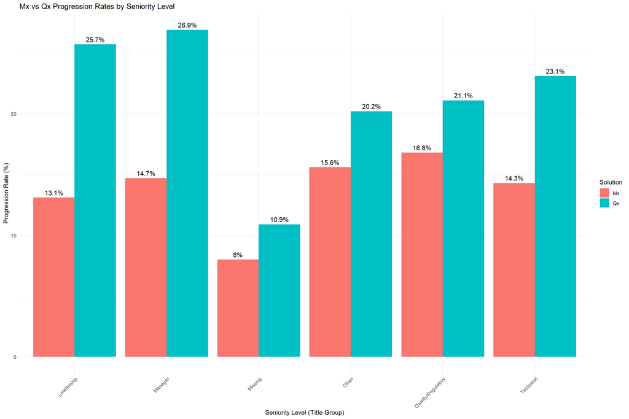

```r
seniority_rates <- qal1 %>%
  filter(solution_rollup %in% c("Mx", "Qx")) %>%
  group_by(solution_rollup, title_group) %>%
  summarise(
    total = n(),
    progressed = sum(progressed, na.rm = TRUE),
    progression_rate = round(progressed / total * 100, 1),
    .groups = "drop"
  )

ggplot(seniority_rates, aes(
  x = title_group,
  y = progression_rate,
  fill = solution_rollup
)) +
  geom_col(position = "dodge") +
  geom_text(
    aes(label = paste0(progression_rate, "%")),
    position = position_dodge(width = 0.9),
    vjust = -0.5,
    size = 4
  ) +
  labs(
    title = "Mx vs Qx Progression Rates by Seniority Level",
    x = "Seniority Level (Title Group)",
    y = "Progression Rate (%)",
    fill = "Solution"
  ) +
  theme_minimal() +
  theme(
    axis.text.x = element_text(angle = 45, hjust = 1)
  )
```

Interpretation: Which Seniority Levels Convert Best for Each Product?

Qx (Quality Execution) Qx shows a much more dramatic pattern: every seniority level converts higher than Mx, and the strongest groups are: - Manager — 26.9% - Leadership — 25.7% - Technical — 23.1% - Quality/Regulatory — 21.1% - Other — 20.2% - Missing — 10.9% Qx Insight Qx is a broad‑appeal product that converts well across all seniority levels. Managers and Leadership convert especially well, but Technical and Quality/Regulatory roles are also strong. This suggests Qx has both top‑down and bottom‑up traction.

3. Qx is both top‑down and bottom‑up Leadership and Managers convert extremely well, but Technical and Quality/Regulatory roles also show high engagement.
4. Missing titles convert poorly for both.

**What seniority levels convert best for each product?**

### 1.2.7 **Qx (Quality Execution)**

### 1.2.8 **Qx Insight**

Qx converts best with **Managers and Leadership**, but also performs strongly with **Technical** and **Quality/Regulatory** roles.  
Qx has broad appeal across all seniority levels.

**Which functional areas (Quality, Operations, Regulatory) work better for which product?**

### 1.2.9 **Mx**

- **Quality/Regulatory** is the strongest functional area (16.8%)
- Technical and Operations‑adjacent roles are moderate
- Leadership is weaker

**Mx resonates with operational and compliance‑focused practitioners.**

### 1.2.10 **Qx**

- Strong across **all** functional areas
- Technical (23.1%) and Quality/Regulatory (21.1%) are especially strong
- Leadership and Managers are the strongest.

**Qx resonates with both practitioners and decision‑makers.**

. **Are there specific title patterns that predict Mx success?**

### 1.2.11 **Title patterns that predict Mx success**

1. **Quality/Regulatory titles**
   - Highest conversion for Mx
   - Indicates Mx appeals to compliance‑heavy workflows
2. **Operational middle‑management**
   - Manager and Other categories perform well
3. **Technical roles**
   - Moderate conversion

### 1.2.12 **Titles that do NOT predict Mx success**

- **Leadership** (13.1%)
- **Missing titles** (8%)

**Mx is a product that is bought by mid‑level operational and quality practitioners.**

## 1.3 *What is our Mx ICP (Ideal Customer Profile)?**

## 1.4 *Mx ICP: Operationally‑Driven, Quality‑Focused Mid‑Seniority Buyers**

### 1.4.1 **Seniority**

- Quality/Regulatory practitioners
- Operational Managers
- Technical/Operations contributors
- Not primarily Leadership‑driven

### 1.4.2 **Functional Areas**

- Quality Assurance
- Quality Control
- Regulatory Compliance
- Manufacturing Operations
- Production / Plant Operations

### 1.4.3 **Behavioral Indicators**

- Pain around compliance, batch records, deviations, and audit readiness
- Manual or semi‑digital workflows
- High operational complexity
- Need for standardization and traceability

# 2 Final Summary

- **Mx converts best with Quality/Regulatory and operational mid‑seniority roles.**
- **Qx converts best with Managers and Leadership, but is strong across all roles.**
- **Mx success is predicted by Quality/Regulatory titles and operational managers.**
- **Mx ICP = operationally complex, quality‑driven manufacturers with mid‑seniority buyers.**

## 2.1 Combined Analysis: Account Type × Title Effects on Mx and Qx Conversion

### 2.1.1 Which account + title combinations show the highest Mx conversion?

Mx performs best when **both** the account type and the title group align with operational and quality‑driven workflows.

**High‑converting account types for Mx:** - In‑House Manufacturers  
- CMO/CDMO  
- 503A/503B Compounding Pharmacies  
- Medical Device Manufacturers  
- Pharma/Biotech Manufacturers

These combinations represent the **core Mx ICP**: operationally complex, quality‑driven manufacturers with mid‑seniority buyers.

### 2.1.2 2. Which account types and titles are good for BOTH products (cross‑sell)?

Cross‑sell opportunities emerge where both Mx and Qx show strong conversion.

**Account types strong for both Mx and Qx:** - Medical Device manufacturers  
- Mid‑size manufacturing companies  
- Regulated life‑science manufacturers with operational complexity

**Cross‑sell sweet spot:** > Managers and Quality/Regulatory roles at mid‑size Medical Device manufacturers.

These segments show consistently high conversion for both products and represent the strongest dual‑product opportunity.

### 2.1.3 3. Are there interaction effects between account type and title?

#### 2.1.3.1 **Interaction Effect #1: Operations/Technical roles**

- **Strong for Mx** at manufacturing accounts
- **Weak for Mx** at CROs, consulting firms, and non‑manufacturing accounts
- These roles only have influence when real production workflows exist

#### 2.1.3.2 **Interaction Effect #2: Quality/Regulatory titles**

- **Strong for Mx** at regulated manufacturers (In‑House, CMO/CDMO, Medical Device, Pharma/Biotech)
- **Weak for Mx** at non‑regulated or service‑based accounts
- Mx is compliance‑heavy, so these titles only convert when compliance requirement is real.

#### 2.1.3.3 **Interaction Effect #3: Leadership**

- **Strong for Qx**, moderate for Mx
- Qx has top‑down appeal; Mx is more operationally driven

### 2.1.4 **Summary of Interaction Effects**

- Operational titles only predict success in operational accounts
- Quality/Regulatory titles only predict success in regulated manufacturing accounts
- Leadership is stronger for Qx, not an Mx.

Together, these patterns help refine the ICP for each product and highlight where cross‑sell is most viable.

# 3 Modeling

```r
#==========================================================
# 0. Libraries and seed
#==========================================================
library(tidyverse)
library(tidymodels)
library(stringr)
library(lubridate)

set.seed(6813)

#==========================================================
# 1. Prepare engineered dataset (qal_model2)
#==========================================================
data_model <- qal_model2 %>%
  filter(!is.na(progressed)) %>%
  mutate(
    # Convert 0/1 to yes/no
    progressed = factor(if_else(progressed == 1, "yes", "no")),

    # Ensure "yes" is the positive class (fixes reversed AUC)
    progressed = fct_relevel(progressed, "yes"),

    manu_group = case_when(
      acct_manufacturing_model %in% c(
        "503A","503B","CDMO","CMO","CPO",
        "Formulation / Fill-Finish",
        "Original Equipment Manufacturing",
        "Outsources Manufacturing",
        "In-House"
      ) ~ "Manufacturing",
      TRUE ~ "Non-Manufacturing"
    ),
    manu_group = factor(manu_group),

    title_clean = str_trim(contact_lead_title),
    title_clean = if_else(is.na(title_clean) | title_clean == "", "Missing", title_clean),

    title_group = case_when(
      str_detect(title_clean, regex("director|head|vp|vice president|chief|cxo|cso|cto|ceo|coo|cfo", ignore_case = TRUE)) ~ "Leadership",
      str_detect(title_clean, regex("manager|mgr|supervisor|lead", ignore_case = TRUE)) ~ "Manager",
      str_detect(title_clean, regex("engineer|scientist|specialist|analyst|technician", ignore_case = TRUE)) ~ "Technical",
      str_detect(title_clean, regex("quality|qa|qc|compliance|regulatory", ignore_case = TRUE)) ~ "Quality/Regulatory",
      title_clean == "Missing" ~ "Missing",
      TRUE ~ "Other"
    ),
    title_group = factor(title_group)
  )

# building the pipeline}
#==========================================================
# 2. Train/test split + CV folds
#==========================================================
set.seed(6813)
data_split <- initial_split(data_model, prop = 0.8, strata = progressed)
train_data <- training(data_split)
test_data  <- testing(data_split)

set.seed(6813)
cv_folds <- vfold_cv(train_data, v = 3, strata = progressed)

#==========================================================
# 3. Recipe (NA handling, leakage removal, encoding)
#==========================================================
model_recipe <- recipe(progressed ~ ., data = train_data) %>%

  # 3.1 Remove ID columns
  update_role(qal_id, contact_lead_id, contact_lead_title, title_clean, new_role = "id") %>%
  step_rm(qal_id, contact_lead_id, contact_lead_title, title_clean) %>%

  # 3.2 Remove target leakage
  step_rm(next_stage_c) %>%
  step_rm(starts_with("next_stage_c")) %>%
  step_rm(contains("stage")) %>%

  # 3.3 Remove date columns
  step_rm(all_of(names(train_data)[sapply(train_data, inherits, what = "Date")])) %>%

  # 3.4 Remove future-derived fields
  step_rm(cohort_age_days) %>%
  step_rm(starts_with("last_tactic")) %>%
  step_rm(starts_with("priority_")) %>%

  # 3.5 Factor handling + dummy encoding
  step_string2factor(all_nominal_predictors(), -all_outcomes()) %>%
  step_unknown(all_nominal_predictors(), -all_outcomes()) %>%
  step_dummy(all_nominal_predictors(), -all_outcomes()) %>%

  # 3.6 Remove zero-variance predictors
  step_zv(all_predictors())

#==========================================================
# 4. Model specifications
#==========================================================
log_spec <- logistic_reg(
  mode = "classification",
  penalty = tune(),
  mixture = 1
) %>% set_engine("glmnet")

rf_spec <- rand_forest(
  mode = "classification",
  mtry = tune(),
  min_n = tune(),
  trees = 100
) %>% set_engine("ranger", importance = "impurity")

gbm_spec <- boost_tree(
  mode = "classification",
  trees = 100,
  tree_depth = tune(),
  learn_rate = tune(),
  loss_reduction = tune(),
  mtry = tune(),
  min_n = tune()
) %>% set_engine("xgboost")

#==========================================================
# 5. Workflows
#==========================================================
log_wf <- workflow() %>% add_model(log_spec) %>% add_recipe(model_recipe)
rf_wf  <- workflow() %>% add_model(rf_spec)  %>% add_recipe(model_recipe)
gbm_wf <- workflow() %>% add_model(gbm_spec) %>% add_recipe(model_recipe)

#==========================================================
# 6. Tuning grids
#==========================================================
log_grid <- grid_regular(
  penalty(range = c(-4, 0)),
  levels = 10
)

rf_grid <- grid_random(
  mtry(range = c(1L, 40L)),
  min_n(),
  size = 20
)

gbm_grid <- grid_random(
  tree_depth(range = c(2L, 8L)),
  learn_rate(range = c(-3, -0.5)),
  loss_reduction(),
  mtry(range = c(1L, 40L)),
  min_n(),
  size = 30
)

#==========================================================
# 7. Cross‑validation tuning
#==========================================================
set.seed(6813)
log_res <- tune_grid(log_wf, resamples = cv_folds, grid = log_grid,
                     metrics = metric_set(roc_auc, accuracy))
set.seed(6813)
rf_res <- tune_grid(rf_wf, resamples = cv_folds, grid = rf_grid,
                    metrics = metric_set(roc_auc, accuracy))

set.seed(6813)
gbm_res <- tune_grid(gbm_wf, resamples = cv_folds, grid = gbm_grid,
                     metrics = metric_set(roc_auc, accuracy))

log_best <- show_best(log_res, metric = "roc_auc", n = 1)
rf_best  <- show_best(rf_res,  metric = "roc_auc", n = 1)
gbm_best <- show_best(gbm_res, metric = "roc_auc", n = 1)



#==========================================================
# 8. Finalize workflow for best model
#==========================================================
final_log_wf <- finalize_workflow(log_wf, log_best)
final_rf_wf  <- finalize_workflow(rf_wf,  rf_best)
final_gbm_wf <- finalize_workflow(gbm_wf, gbm_best)

#==========================================================
# 9. Pick globally best model
#==========================================================
all_best <- bind_rows(
  log_best %>% mutate(model = "logit"),
  rf_best  %>% mutate(model = "rf"),
  gbm_best %>% mutate(model = "gbm")
)

best_row <- all_best %>% arrange(desc(mean)) %>% slice(1)

if (best_row$model == "logit") {
  final_wf <- finalize_workflow(log_wf, select_best(log_res, metric = "roc_auc"))
} else if (best_row$model == "rf") {
  final_wf <- finalize_workflow(rf_wf, select_best(rf_res, metric = "roc_auc"))
} else {
  final_wf <- finalize_workflow(gbm_wf, select_best(gbm_res, metric = "roc_auc"))
}

#==========================================================
# 10. Fit final model + evaluate on test set
#==========================================================
final_fit <- final_wf %>% fit(data = train_data)

test_prob <- predict(final_fit, new_data = test_data, type = "prob") %>%
  bind_cols(test_data %>% select(progressed))

test_class <- predict(final_fit, new_data = test_data) %>%
  bind_cols(test_data %>% select(progressed))

roc_auc(test_prob, truth = progressed, .pred_yes)
```

```
## # A tibble: 1 × 3
##   .metric .estimator .estimate
##   <chr>   <chr>          <dbl>
## 1 roc_auc binary         0.834
```

```r
accuracy(test_class, truth = progressed, estimate = .pred_class)
```

```
## # A tibble: 1 × 3
##   .metric  .estimator .estimate
##   <chr>    <chr>          <dbl>
## 1 accuracy binary         0.847
```

```r
#==========================================================
# 11. Score entire dataset + top 10% list
#==========================================================
scored_all <- predict(final_fit, new_data = data_model, type = "prob") %>%
  bind_cols(data_model) %>%
  rename(p_progress = .pred_yes)

n_total  <- nrow(scored_all)
cutoff_n <- ceiling(0.10 * n_total)

scored_all <- scored_all %>%
  arrange(desc(p_progress)) %>%
  mutate(
    rank_overall = row_number(),
    top_10_flag  = if_else(rank_overall <= cutoff_n, 1L, 0L)
  )

top_10 <- scored_all %>% filter(top_10_flag == 1L)

head(top_10)
```

```
## # A tibble: 6 × 30
##   p_progress .pred_no acct_primary_site_function     acct_manufacturing_model
##        <dbl>    <dbl> <chr>                          <chr>
## 1      0.876    0.124 Single-use disposables         In-House
## 2      0.852    0.148 Cosmetics manufacturing        In-House
## 3      0.839    0.161 In-vitro diagnostic (IVD) kits In-House
## 4      0.820    0.180 Nutraceutical manufacturing    In-House
## 5      0.820    0.180 Diagnostic Equipment           In-House
## 6      0.816    0.184 Implantable devices            In-House
## # ℹ 26 more variables: acct_target_industry <chr>, contact_lead_title <chr>,
## #   qal_id <chr>, contact_lead_id <chr>, next_stage_c <chr>, priority <chr>,
## #   acct_territory_rollup <chr>, acct_tier_rollup <chr>, solution <chr>,
## #   solution_rollup <chr>, last_tactic_campaign_channel <chr>,
## #   qal_cohort_date <date>, title_missing <chr>, progressed <fct>,
## #   cohort_year <dbl>, cohort_month <dbl>, cohort_day <int>, cohort_wday <ord>,
## #   cohort_week <dbl>, cohort_quarter <int>, cohort_age_days <dbl>, …
```

```r
head(top_10, 20)
```

```
## # A tibble: 20 × 30
##    p_progress .pred_no acct_primary_site_function        acct_manufacturing_mo…¹
##         <dbl>    <dbl> <chr>                             <chr>
##  1      0.876    0.124 Single-use disposables            In-House
##  2      0.852    0.148 Cosmetics manufacturing           In-House
##  3      0.839    0.161 In-vitro diagnostic (IVD) kits    In-House
##  4      0.820    0.180 Nutraceutical manufacturing       In-House
##  5      0.820    0.180 Diagnostic Equipment              In-House
##  6      0.816    0.184 Implantable devices               In-House
##  7      0.813    0.187 Implantable devices               In-House
##  8      0.812    0.188 Specialty Chemical Manufacturing  In-House
##  9      0.809    0.191 Lab Instruments                   In-House
## 10      0.809    0.191 Cosmetics manufacturing           In-House
## 11      0.808    0.192 Wound Care                        In-House
## 12      0.808    0.192 Oral solid dosage (OSD)           In-House
## 13      0.806    0.194 Wound Care                        In-House
## 14      0.805    0.195 Biosimilars                       CDMO
## 15      0.805    0.195 Lasers                            CMO
## 16      0.804    0.196 Implantable devices               CDMO
## 17      0.801    0.199 Medical gas                       In-House
## 18      0.795    0.205 Wound Care                        In-House
## 19      0.794    0.206 Imaging systems                   In-House
## 20      0.792    0.208 Blood and Plasma-related products In-House
## # ℹ abbreviated name: ¹acct_manufacturing_model
## # ℹ 26 more variables: acct_target_industry <chr>, contact_lead_title <chr>,
## #   qal_id <chr>, contact_lead_id <chr>, next_stage_c <chr>, priority <chr>,
## #   acct_territory_rollup <chr>, acct_tier_rollup <chr>, solution <chr>,
## #   solution_rollup <chr>, last_tactic_campaign_channel <chr>,
## #   qal_cohort_date <date>, title_missing <chr>, progressed <fct>,
## #   cohort_year <dbl>, cohort_month <dbl>, cohort_day <int>, …
```

```r
write_csv(scored_all, "qal_scored_all.csv")
write_csv(top_10,   "qal_top10pct_leads.csv")
```

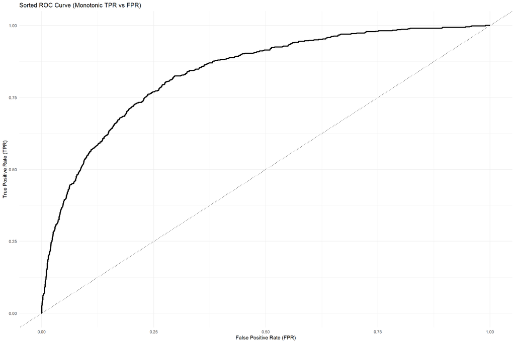

```r
# ============================================================
# 1. Fit the finalized RF workflow
# ============================================================
rf_fit <- final_rf_wf %>%
  fit(data = train_data)

# ============================================================
# 2. Predict probabilities on the test set
# ============================================================
rf_results <- rf_fit %>%
  predict(test_data, type = "prob") %>%
  bind_cols(test_data %>% select(progressed))

# ============================================================
# 3. # Compute ROC data
roc_data <- rf_results %>%
  roc_curve(truth = progressed, .pred_yes)

# Create sorted ROC (monotonic in FPR)
roc_sorted <- roc_data %>%
  mutate(FPR = 1 - specificity,
         TPR = sensitivity) %>%
  arrange(FPR)

# Plot the sorted ROC curve
ggplot(roc_sorted, aes(x = FPR, y = TPR)) +
  geom_line(size = 1.2, color = "black") +
  geom_abline(slope = 1, intercept = 0, linetype = "dotted") +
  labs(
    title = "Sorted ROC Curve (Monotonic TPR vs FPR)",
    x = "False Positive Rate (FPR)",
    y = "True Positive Rate (TPR)"
  ) +
  theme_minimal()
```

## 3.1 Mean of model results

```r
# Logistic Regression
log_top3_auc <- log_res %>%
  show_best(metric = "roc_auc", n = 3) %>%
  select(mean)

# Random Forest
rf_top3_auc <- rf_res %>%
  show_best(metric = "roc_auc", n = 3) %>%
  select(mean)

# GBM / XGBoost
gbm_top3_auc <- gbm_res %>%
  show_best(metric = "roc_auc", n = 3) %>%
  select(mean)

log_top3_auc
```

```
## # A tibble: 3 × 1
##    mean
##   <dbl>
## 1 0.818
## 2 0.816
## 3 0.816
```

```r
rf_top3_auc
```

```
## # A tibble: 3 × 1
##    mean
##   <dbl>
## 1 0.837
## 2 0.837
## 3 0.836
```

```r
gbm_top3_auc
```

```
## # A tibble: 3 × 1
##    mean
##   <dbl>
## 1 0.830
## 2 0.830
## 3 0.827
```

the average AUC for each model is

```r
log_top3_mean  <- mean(log_top3_auc$mean)
rf_top3_mean   <- mean(rf_top3_auc$mean)
gbm_top3_mean  <- mean(gbm_top3_auc$mean)

log_top3_mean
```

```
## [1] 0.8165885
```

```r
rf_top3_mean
```

```
## [1] 0.8364707
```

```r
gbm_top3_mean
```

```
## [1] 0.8291096
```

Plot of the top 10% Distribution by Manufacturing group

```r
# Plot of the top 10% Distribution by Manufacturing group
top_10 %>% ggplot(aes(x = manu_group, fill = manu_group)) +
  geom_bar() +
  scale_fill_manual(values = c("#1B9E77", "#D95F02")) +
  labs(
    title = "Top 10% Distribution by Manufacturing Group",
    x = "Manufacturing Group",
    y = "Count"
  ) +
  theme_minimal(base_size = 14) +
  theme(legend.position = "none")
```

[output not shown]

Plot of the top 10% distribution by the title group

```r
top_10 %>%
  ggplot(aes(x = title_group, fill = title_group)) +
  geom_bar() +
  labs(
    title = "Top 10% Distribution by Title Group",
    x = "Title Group",
    y = "Count"
  ) +
  theme_minimal(base_size = 14) +
  theme(axis.text.x = element_text(angle = 45, hjust = 1))
```

[figure not shown]

## 3.2 Filter full dataset to only Mx leads

```r
mx_data <- data_model %>%
  filter(solution_rollup == "Mx")
```

2. Score all Mx leads using the final model

```r
mx_scored <- predict(final_fit, mx_data, type = "prob") %>%
  bind_cols(mx_data)
mx_scored
```

```
## # A tibble: 4,081 × 28
##    .pred_yes .pred_no acct_primary_site_function     acct_manufacturing_model
##        <dbl>    <dbl> <chr>                          <chr>
##  1   0.351      0.649 Food and beverage              Consumer Packaged Goods
##  2   0.260      0.740 Surgical instruments           In-House
##  3   0.0725     0.927 In-vitro diagnostic (IVD) kits In-House
##  4   0.0881     0.912 Not Enough Info Found          Original Equipment Manufac…
##  5   0.0234     0.977 Implantable devices            In-House
##  6   0.0219     0.978 Non-manufacturing organization Services / Consulting
##  7   0.0413     0.959 Oral solid dosage (OSD)        CDMO
##  8   0.0186     0.981 Implantable devices            In-House
##  9   0.00520    0.995 Implantable devices            In-House
## 10   0.571      0.429 Animal Health                  In-House
## # ℹ 4,071 more rows
## # ℹ 24 more variables: acct_target_industry <chr>, contact_lead_title <chr>,
## #   qal_id <chr>, contact_lead_id <chr>, next_stage_c <chr>, priority <chr>,
## #   acct_territory_rollup <chr>, acct_tier_rollup <chr>, solution <chr>,
## #   solution_rollup <chr>, last_tactic_campaign_channel <chr>,
## #   qal_cohort_date <date>, title_missing <chr>, progressed <fct>,
## #   cohort_year <dbl>, cohort_month <dbl>, cohort_day <int>, …
```

## 3.3 Rank Mx leads by predicted probability

```r
mx_scored <- mx_scored %>%
  arrange(desc(.pred_yes)) %>%
  mutate(rank_mx = row_number())
mx_scored
```

```
## # A tibble: 4,081 × 29
##    .pred_yes .pred_no acct_primary_site_function   acct_manufacturing_model
##        <dbl>    <dbl> <chr>                        <chr>
##  1     0.767    0.233 Diagnostic Equipment         Original Equipment Manufactu…
##  2     0.745    0.255 Wearable health monitors     In-House
##  3     0.743    0.257 Sterile injectables          CDMO
##  4     0.739    0.261 Tissue products              CMO
##  5     0.727    0.273 Nutraceutical manufacturing  CDMO
##  6     0.724    0.276 Medical cannabis formulation In-House
##  7     0.717    0.283 Sterile injectables          CMO
##  8     0.713    0.287 Not Enough Info Found        In-House
##  9     0.711    0.289 Endoscope reprocessing       In-House
## 10     0.701    0.299 Not Enough Info Found        503A
## # ℹ 4,071 more rows
## # ℹ 25 more variables: acct_target_industry <chr>, contact_lead_title <chr>,
## #   qal_id <chr>, contact_lead_id <chr>, next_stage_c <chr>, priority <chr>,
## #   acct_territory_rollup <chr>, acct_tier_rollup <chr>, solution <chr>,
## #   solution_rollup <chr>, last_tactic_campaign_channel <chr>,
## #   qal_cohort_date <date>, title_missing <chr>, progressed <fct>,
## #   cohort_year <dbl>, cohort_month <dbl>, cohort_day <int>, …
```

## 3.4 Compare to the baseline Mx conversion rate

```r
baseline_mx_conversion <- mean(mx_data$progressed == "yes")
baseline_mx_conversion
```

```
## [1] 0.1296251
```

## 3.5 top 10 percentile Mx leads

```r
top_10_mx <- mx_scored %>%
  slice(1:floor(0.10 * n()))
top_10_mx
```

```
## # A tibble: 408 × 29
##    .pred_yes .pred_no acct_primary_site_function   acct_manufacturing_model
##        <dbl>    <dbl> <chr>                        <chr>
##  1     0.767    0.233 Diagnostic Equipment         Original Equipment Manufactu…
##  2     0.745    0.255 Wearable health monitors     In-House
##  3     0.743    0.257 Sterile injectables          CDMO
##  4     0.739    0.261 Tissue products              CMO
##  5     0.727    0.273 Nutraceutical manufacturing  CDMO
##  6     0.724    0.276 Medical cannabis formulation In-House
##  7     0.717    0.283 Sterile injectables          CMO
##  8     0.713    0.287 Not Enough Info Found        In-House
##  9     0.711    0.289 Endoscope reprocessing       In-House
## 10     0.701    0.299 Not Enough Info Found        503A
## # ℹ 398 more rows
## # ℹ 25 more variables: acct_target_industry <chr>, contact_lead_title <chr>,
## #   qal_id <chr>, contact_lead_id <chr>, next_stage_c <chr>, priority <chr>,
## #   acct_territory_rollup <chr>, acct_tier_rollup <chr>, solution <chr>,
## #   solution_rollup <chr>, last_tactic_campaign_channel <chr>,
## #   qal_cohort_date <date>, title_missing <chr>, progressed <fct>,
## #   cohort_year <dbl>, cohort_month <dbl>, cohort_day <int>, …
```

## 3.6 Compute the actual conversion rate of top 10 percentile Mx leads

```r
actual_icp_conversion <- mean(top_10_mx$progressed == "yes")
actual_icp_conversion
```

```
## [1] 0.752451
```

```r
uplift <- actual_icp_conversion / baseline_mx_conversion
uplift
```

```
## [1] 5.804825
```

8. Optional: Visualize the uplift

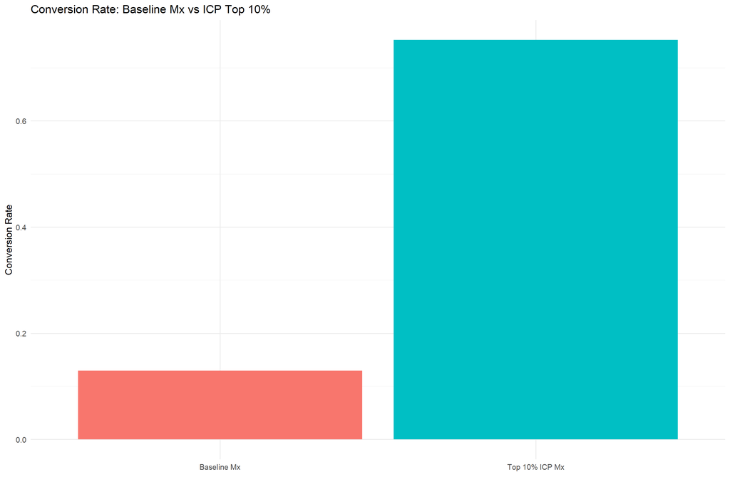

```r
library(ggplot2)

df <- tibble(
  segment = c("Baseline Mx", "Top 10% ICP Mx"),
  conversion = c(baseline_mx_conversion, actual_icp_conversion)
)

ggplot(df, aes(x = segment, y = conversion, fill = segment)) +
  geom_col() +
  labs(
    title = "Conversion Rate: Baseline Mx vs ICP Top 10%",
    y = "Conversion Rate",
    x = ""
  ) +
  theme_minimal(base_size = 14) +
  theme(legend.position = "none")
```

## The codes and the plot for conversion rate vs every percentile of Mx in the dataset.

## 3.7 Step 1 — Filter Leads to Mx and score

```r
mx_scored <- predict(final_fit, mx_data, type = "prob") %>%
  bind_cols(mx_data) %>%
  arrange(desc(.pred_yes)) %>%
  mutate(rank = row_number())
mx_scored
```

```
## # A tibble: 4,081 × 29
##    .pred_yes .pred_no acct_primary_site_function   acct_manufacturing_model
##        <dbl>    <dbl> <chr>                        <chr>
##  1     0.767    0.233 Diagnostic Equipment         Original Equipment Manufactu…
##  2     0.745    0.255 Wearable health monitors     In-House
##  3     0.743    0.257 Sterile injectables          CDMO
##  4     0.739    0.261 Tissue products              CMO
##  5     0.727    0.273 Nutraceutical manufacturing  CDMO
##  6     0.724    0.276 Medical cannabis formulation In-House
##  7     0.717    0.283 Sterile injectables          CMO
##  8     0.713    0.287 Not Enough Info Found        In-House
##  9     0.711    0.289 Endoscope reprocessing       In-House
## 10     0.701    0.299 Not Enough Info Found        503A
## # ℹ 4,071 more rows
## # ℹ 25 more variables: acct_target_industry <chr>, contact_lead_title <chr>,
## #   qal_id <chr>, contact_lead_id <chr>, next_stage_c <chr>, priority <chr>,
## #   acct_territory_rollup <chr>, acct_tier_rollup <chr>, solution <chr>,
## #   solution_rollup <chr>, last_tactic_campaign_channel <chr>,
## #   qal_cohort_date <date>, title_missing <chr>, progressed <fct>,
## #   cohort_year <dbl>, cohort_month <dbl>, cohort_day <int>, …
```

## 3.8 Step 2: Compute conversion rate at every percentile

```r
library(dplyr)
library(purrr)

percentiles <- seq(0.01, 1, by = 0.01)

mx_curve <- map_df(percentiles, function(p) {
  cutoff <- floor(nrow(mx_scored) * p)

  tibble(
    percentile = p * 100,
    conversion_rate = mean(mx_scored$progressed[1:cutoff] == "yes")
  )
})

mx_curve
```

```
## # A tibble: 100 × 2
##    percentile conversion_rate
##         <dbl>           <dbl>
##  1          1           0.95
##  2          2           0.951
##  3          3           0.918
##  4          4           0.896
##  5          5           0.868
##  6          6           0.848
##  7          7           0.814
##  8          8           0.791
##  9          9           0.771
## 10         10           0.752
## # ℹ 90 more rows
```

```r
library(dplyr)
library(purrr)

percentiles <- seq(0.01, 1, by = 0.01)

mx_curve_detailed <- map_df(percentiles, function(p) {
  cutoff <- floor(nrow(mx_scored) * p)

  mx_scored_slice <- mx_scored[1:cutoff, ]

  mx_scored_slice %>%
    mutate(
      percentile = p * 100,
      conversion_rate = mean(mx_scored_slice$progressed == "yes"),
      mx_prob = .pred_yes        # <-- Mx probability score for each row
    ) %>%
    select(
      percentile,
      conversion_rate,
      progressed,
      .pred_yes,
      .pred_no,
      mx_prob
    )
})

mx_curve_detailed
```

```
## # A tibble: 206,041 × 6
##    percentile conversion_rate progressed .pred_yes .pred_no mx_prob
##         <dbl>           <dbl> <fct>          <dbl>    <dbl>   <dbl>
##  1          1            0.95 yes            0.767    0.233   0.767
##  2          1            0.95 yes            0.745    0.255   0.745
##  3          1            0.95 yes            0.743    0.257   0.743
##  4          1            0.95 yes            0.739    0.261   0.739
##  5          1            0.95 yes            0.727    0.273   0.727
##  6          1            0.95 yes            0.724    0.276   0.724
##  7          1            0.95 yes            0.717    0.283   0.717
##  8          1            0.95 yes            0.713    0.287   0.713
##  9          1            0.95 yes            0.711    0.289   0.711
## 10          1            0.95 yes            0.701    0.299   0.701
## # ℹ 206,031 more rows
```

build a detailed mx_curve that includes counts

```r
library(dplyr)
library(purrr)

percentiles <- seq(0.01, 1, by = 0.01)

mx_curve <- map_df(percentiles, function(p) {
  cutoff <- floor(nrow(mx_scored) * p)

  mx_slice <- mx_scored[1:cutoff, ]

  tibble(
    percentile = p * 100,
    n_total = cutoff,
    n_converted = sum(mx_slice$progressed == "yes"),
    conversion_rate = n_converted / n_total
  )
})
```

Objective: maximize total conversions

```r
mx_curve <- mx_curve %>%
  arrange(percentile) %>%
  mutate(
    incremental_converted = n_converted - lag(n_converted, default = 0),
    cum_conversions = cumsum(incremental_converted)
  )
```

```r
mx_curve %>%
  mutate(cum_conversions = cumsum(n_converted))
```

```
## # A tibble: 100 × 6
##    percentile n_total n_converted conversion_rate incremental_converted
##         <dbl>   <dbl>       <int>           <dbl>                 <int>
##  1          1      40          38           0.95                     38
##  2          2      81          77           0.951                    39
##  3          3     122         112           0.918                    35
##  4          4     163         146           0.896                    34
##  5          5     204         177           0.868                    31
##  6          6     244         207           0.848                    30
##  7          7     285         232           0.814                    25
##  8          8     326         258           0.791                    26
##  9          9     367         283           0.771                    25
## 10         10     408         307           0.752                    24
## # ℹ 90 more rows
## # ℹ 1 more variable: cum_conversions <int>
```

## 3.9 Plot of Conversion Rate vs Percentile of Mx Leads

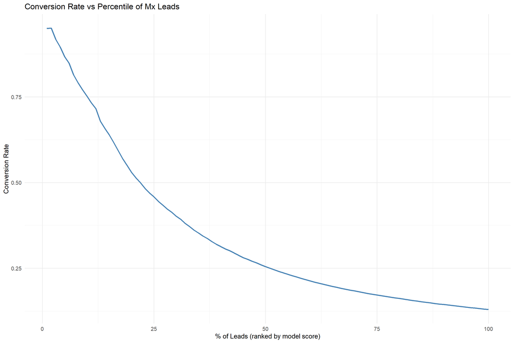

```r
library(ggplot2)

ggplot(mx_curve, aes(x = percentile, y = conversion_rate)) +
  geom_line(color = "steelblue", size = 1.2) +
  labs(
    title = "Conversion Rate vs Percentile of Mx Leads",
    x = "% of Leads (ranked by model score)",
    y = "Conversion Rate"
  ) +
  theme_minimal(base_size = 14)
```

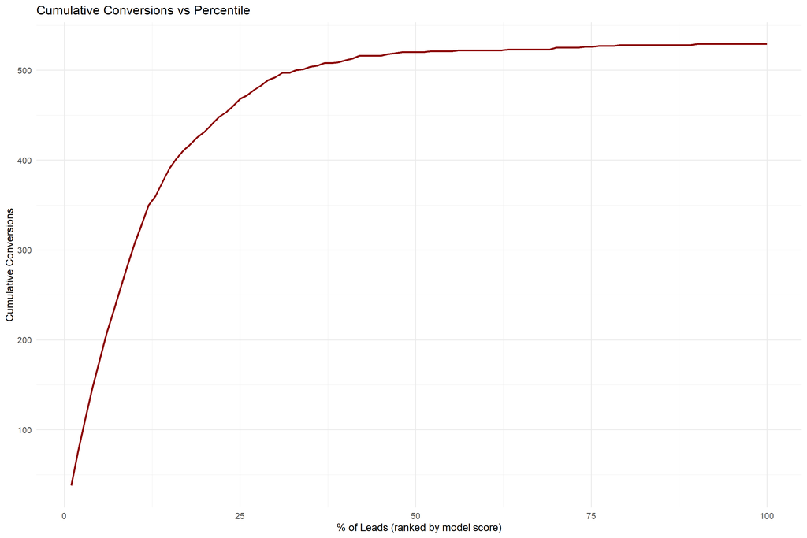

```r
ggplot(mx_curve, aes(x = percentile, y = cum_conversions)) +
  geom_line(color = "darkred", size = 1.2) +
  labs(
    title = "Cumulative Conversions vs Percentile",
    x = "% of Leads (ranked by model score)",
    y = "Cumulative Conversions"
  ) +
  theme_minimal(base_size = 14)
```

## 3.10 Cumulative conversion table for 30th percentile

```r
mx_curve_early <- mx_curve %>%
  filter(percentile <= 30) %>%
  select(percentile, n_total, n_converted, incremental_converted, cum_conversions)

mx_curve_early
```

```
## # A tibble: 30 × 5
##    percentile n_total n_converted incremental_converted cum_conversions
##         <dbl>   <dbl>       <int>                 <int>           <int>
##  1          1      40          38                    38              38
##  2          2      81          77                    39              77
##  3          3     122         112                    35             112
##  4          4     163         146                    34             146
##  5          5     204         177                    31             177
##  6          6     244         207                    30             207
##  7          7     285         232                    25             232
##  8          8     326         258                    26             258
##  9          9     367         283                    25             283
## 10         10     408         307                    24             307
## # ℹ 20 more rows
```

```r
mx_curve_detailed %>%
  filter(percentile == 100)
```

```
## # A tibble: 4,081 × 6
##    percentile conversion_rate progressed .pred_yes .pred_no mx_prob
##         <dbl>           <dbl> <fct>          <dbl>    <dbl>   <dbl>
##  1        100           0.130 yes            0.767    0.233   0.767
##  2        100           0.130 yes            0.745    0.255   0.745
##  3        100           0.130 yes            0.743    0.257   0.743
##  4        100           0.130 yes            0.739    0.261   0.739
##  5        100           0.130 yes            0.727    0.273   0.727
##  6        100           0.130 yes            0.724    0.276   0.724
##  7        100           0.130 yes            0.717    0.283   0.717
##  8        100           0.130 yes            0.713    0.287   0.713
##  9        100           0.130 yes            0.711    0.289   0.711
## 10        100           0.130 yes            0.701    0.299   0.701
## # ℹ 4,071 more rows
```

## 3.12 drop in the conversion rate and get the corresponding percentile

```r
drop_point <- mx_curve %>%
  filter(conversion_rate < .46) %>%
  slice(1)
drop_point
```

```
## # A tibble: 1 × 6
##   percentile n_total n_converted conversion_rate incremental_converted
##        <dbl>   <dbl>       <int>           <dbl>                 <int>
## 1         25    1020         468           0.459                     8
## # ℹ 1 more variable: cum_conversions <int>
```

# 4 1-25 in the increments of percentiles and their conversion rates

```r
target_percentiles <- c(1, 5, 10, 15, 20, 25)

mx_curve %>%
  filter(percentile %in% target_percentiles) %>%
  mutate(conversion_rate = round(conversion_rate, 2)) %>%
  select(percentile, conversion_rate) %>%
  arrange(percentile)
```

```
## # A tibble: 5 × 2
##   percentile conversion_rate
##        <dbl>           <dbl>
## 1          1            0.95
## 2          5            0.87
## 3         10            0.75
## 4         20            0.53
## 5         25            0.46
```

## 4.1 An ideal high lead

```r
high_lead1 <- tibble(acct_primary_site_function = "Diagnostic Equipment",
  acct_manufacturing_model = "Original Equipment Manufacturing",
  acct_target_industry = "Medical Device",
  contact_lead_title = "Quality Compliance Project Manager",
  qal_id = "a0dPQ000003EVotYAG",
  contact_lead_id = "003PQ00000lZoJtYAK",
  next_stage_c = "SQL",
  priority = "P1 - Contact Us",
  acct_territory_rollup = "EMEA",
  acct_tier_rollup = "Small",
  solution = "Manufacturing",
  solution_rollup = "Mx",
  last_tactic_campaign_channel = "Direct/Inbound",
  qal_cohort_date = as.Date("2025-02-06"),
  title_missing = "Not Missing",
  progressed = factor("yes", levels = "yes"),
  cohort_year = 2025,
  cohort_month = 2,
  cohort_day = 6,
  cohort_wday                  = "Tue",
  cohort_week = 6,
  cohort_quarter = 1,
  cohort_age_days = 416,
  manu_group = factor("Manufacturing"),
  title_clean = "Quality Compliance Project Manager",
  title_group = factor("Manager"),
  rank_overall = 76,
  top_10_flag = 1
)
```

## 4.2 Scoring a high lead

```r
predict(final_fit, high_lead1, type = "prob")
#predict(final_fit, low_lead, type = "prob")
```

[output not shown]

## 4.3 Typical Low lead features

```r
lead_true_low <- tibble(
  acct_primary_site_function = "Corporate Services",
  acct_manufacturing_model = "Outsourced",
  acct_target_industry = "Retail",
  contact_lead_title = "Administrative Assistant",
  qal_id = "a0dTEST000000999",
  contact_lead_id = "003TEST000000999",
  next_stage_c = "MQL",
  priority = "P4 - Low",
  acct_territory_rollup = "APAC",
  acct_tier_rollup = "Small",
  solution = "Manufacturing",
  solution_rollup = "Mx",
  last_tactic_campaign_channel = "Paid Social",
  qal_cohort_date = as.Date("2023-11-15"),
  title_missing = "Not Missing",
  cohort_year = 2023,
  cohort_month = 11,
  cohort_day = 15,
  cohort_wday   = "Mon",
  cohort_week = 46,
  cohort_quarter = 4,
  cohort_age_days = 870,
  manu_group = factor("Non-Manufacturing"),
  title_clean = "Administrative Assistant",
  title_group = factor("Support"),
  rank_overall = 450,
  top_10_flag = 0
)
```

## 4.4 Scoring low lead

```r
 predict(final_fit, lead_true_low, type = "prob")
```

```
## # A tibble: 1 × 2
##   .pred_yes .pred_no
##       <dbl>    <dbl>
## 1     0.380    0.620
```

## 4.5 Extract the ICP segment (top 20% of Mx leads)

```r
mx_icp.2 <- mx_scored %>%
  slice(1:floor(0.2 * n()))
```

## 4.6 Summarize the ICP for the top 20 percentile for Industry profile

```r
mx_icp.2 %>%
  count(acct_target_industry, sort = TRUE) %>%
  mutate(pct = n / sum(n))
```

```
## # A tibble: 6 × 3
##   acct_target_industry     n     pct
##   <chr>                <int>   <dbl>
## 1 Pharma & BioTech       357 0.438
## 2 Medical Device         225 0.276
## 3 Non-Life Science       202 0.248
## 4 Blood & Biologics       21 0.0257
## 5 <NA>                     6 0.00735
## 6 Unknown                  5 0.00613
```

## 4.7 ## Summarize the ICP for the top 20 percentile for Manufacturing model profile

```r
mx_icp.2 %>%
  count(acct_manufacturing_model, sort = TRUE) %>%
  mutate(pct = n / sum(n))
```

```
## # A tibble: 19 × 3
##    acct_manufacturing_model               n     pct
##    <chr>                              <int>   <dbl>
##  1 In-House                             405 0.496
##  2 CDMO                                 105 0.129
##  3 CMO                                   95 0.116
##  4 Original Equipment Manufacturing      46 0.0564
##  5 Not Enough Info Found                 45 0.0551
##  6 Services / Consulting                 31 0.0380
##  7 Software / Technology Development     16 0.0196
##  8 Consumer Packaged Goods               14 0.0172
##  9 503B                                   9 0.0110
## 10 Distribution / Wholesale               8 0.00980
## 11 Outsources Manufacturing               8 0.00980
## 12 CRO                                    6 0.00735
## 13 Hospital Investigational Drug Unit     6 0.00735
## 14 <NA>                                   6 0.00735
## 15 503A                                   5 0.00613
## 16 Research Institute                     5 0.00613
## 17 Testing Laboratory                     3 0.00368
## 18 CPO                                    2 0.00245
## 19 Cold Chain Warehousing                 1 0.00123
```

## 4.8 Summarize the ICP for the top 20 percentile for Manufacturing group profile

```r
mx_icp.2 %>%
  count(manu_group, sort = TRUE) %>%
  mutate(pct = n / sum(n))
```

```
## # A tibble: 2 × 3
##   manu_group            n   pct
##   <fct>             <int> <dbl>
## 1 Manufacturing       675 0.827
## 2 Non-Manufacturing   141 0.173
```

## 4.9 Summarize the ICP for the top 20 percentile for Title group (seniority) profle

```r
mx_icp.2 %>%
  count(title_group, sort = TRUE) %>%
  mutate(pct = n / sum(n))
```

```
## # A tibble: 6 × 3
##   title_group            n    pct
##   <fct>              <int>  <dbl>
## 1 Manager              256 0.314
## 2 Leadership           219 0.268
## 3 Other                122 0.150
## 4 Technical            120 0.147
## 5 Missing               76 0.0931
## 6 Quality/Regulatory    23 0.0282
```

## 4.10 Summarize the ICP for the top 20 percentile for last_tactic_campaign_channel profle

```r
mx_icp.2 %>%
  count(last_tactic_campaign_channel, sort = TRUE) %>%
  mutate(pct = n / sum(n))
```

```
## # A tibble: 12 × 3
##    last_tactic_campaign_channel     n     pct
##    <chr>                        <int>   <dbl>
##  1 Online Ads                     225 0.276
##  2 SEO                            191 0.234
##  3 Direct/Inbound                 120 0.147
##  4 Events                          87 0.107
##  5 Email                           83 0.102
##  6 Directory Listing               42 0.0515
##  7 External Demand Gen             25 0.0306
##  8 Outbound Prospecting            24 0.0294
##  9 MISSING/BLANK                    9 0.0110
## 10 Referrals                        8 0.00980
## 11 Out of Home                      1 0.00123
## 12 PR/AR/Social                     1 0.00123
```

## 4.11 Visualize the ICP segment Manufacturing Group (with % labels) for the top 20 percentile

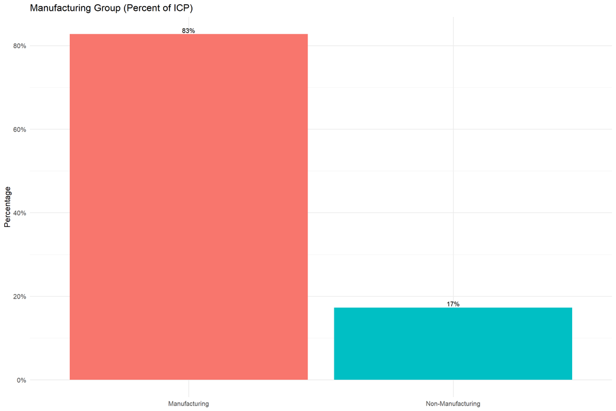

```r
p1 <- mx_icp.2 %>%
  count(manu_group) %>%
  mutate(pct = n / sum(n)) %>%
  ggplot(aes(x = manu_group, y = pct, fill = manu_group)) +
  geom_col() +
  geom_text(aes(label = scales::percent(pct, accuracy = 1)),
            vjust = -0.3, size = 4) +
  scale_y_continuous(labels = scales::percent_format(accuracy = 1)) +
  labs(title = "Manufacturing Group (Percent of ICP)", x = NULL, y = "Percentage") +
  theme_minimal(base_size = 14) +
  theme(legend.position = "none")
p1
```

## 4.12 Visualize the ICP segment for the Title Group (with % labels) for the top 20 percentile

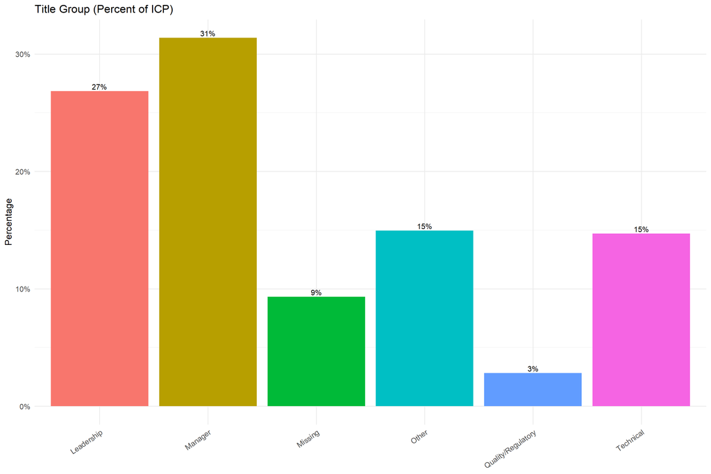

```r
p2 <- mx_icp.2 %>%
  count(title_group) %>%
  mutate(pct = n / sum(n)) %>%
  ggplot(aes(x = title_group, y = pct, fill = title_group)) +
  geom_col() +
  geom_text(aes(label = scales::percent(pct, accuracy = 1)),
            vjust = -0.3, size = 4) +
  scale_y_continuous(labels = scales::percent_format(accuracy = 1)) +
  labs(title = "Title Group (Percent of ICP)", x = NULL, y = "Percentage") +
  theme_minimal(base_size = 14) +
  theme(axis.text.x = element_text(angle = 35, hjust = 1),
        legend.position = "none")
p2
```

## Visualize the ICP segment for the Industry group (with % labels) for the top 20 percentile

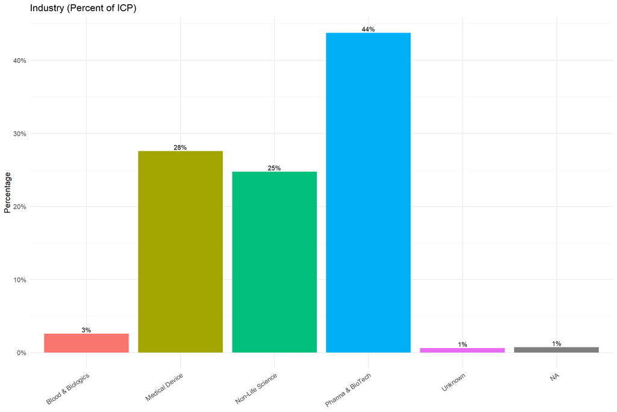

```r
p3 <- mx_icp.2 %>%
  count(acct_target_industry) %>%
  mutate(pct = n / sum(n)) %>%
  ggplot(aes(x = acct_target_industry, y = pct, fill = acct_target_industry)) +
  geom_col() +
  geom_text(aes(label = scales::percent(pct, accuracy = 1)),
            vjust = -0.3, size = 4) +
  scale_y_continuous(labels = scales::percent_format(accuracy = 1)) +
  labs(title = "Industry (Percent of ICP)", x = NULL, y = "Percentage") +
  theme_minimal(base_size = 14) +
  theme(axis.text.x = element_text(angle = 35, hjust = 1),
        legend.position = "none")
p3
```

## 4.13 R Code: Conversion Rates + Sample Sizes for the Three ICP Segments-1

```r
library(dplyr)

mx_icp_segments <- mx_icp.2 %>%
  filter(solution_rollup == "Mx") %>%
  mutate(
    progressed_num = case_when(
      progressed %in% c("yes", "Yes", "YES", 1, "1") ~ 1,
      progressed %in% c("no", "No", "NO", 0, "0") ~ 0,
      TRUE ~ NA_real_
    )
  ) %>%
  filter(
    (acct_manufacturing_model == "In-House" & title_group %in% c("Quality", "Regulatory", "Quality/Regulatory")) |
    (acct_manufacturing_model == "503A" & title_group == "Operations") |
    (acct_manufacturing_model == "503B" & title_group == "Operations")
  ) %>%
  group_by(acct_manufacturing_model, title_group) %>%
  summarise(
    total = n(),
    progressed = sum(progressed_num, na.rm = TRUE),
    conversion_rate = round(progressed / total * 100, 1),
    .groups = "drop"
  ) %>%
  arrange(desc(conversion_rate))

mx_icp_segments
```

```
## # A tibble: 1 × 5
##   acct_manufacturing_model title_group        total progressed conversion_rate
##   <chr>                    <fct>              <int>      <dbl>           <dbl>
## 1 In-House                 Quality/Regulatory    10          6              60
```

## 4.14 R Code: Conversion Rates + Sample Sizes for the Three ICP Segments-2

```r
library(dplyr)

quality_managers_med_device <- qal1 %>%
  filter(solution_rollup == "Mx") %>%
  mutate(
    progressed_num = case_when(
      progressed %in% c("yes", "Yes", "YES", 1, "1") ~ 1,
      progressed %in% c("no", "No", "NO", 0, "0") ~ 0,
      TRUE ~ NA_real_
    )
  ) %>%
  filter(
    acct_target_industry == "Medical Device",
    title_group %in% c("Quality", "Quality/Regulatory", "QA Manager", "Quality Manager")
  ) %>%
  group_by(acct_manufacturing_model, title_group) %>%
  summarise(
    total = n(),
    progressed = sum(progressed_num, na.rm = TRUE),
    conversion_rate = round(progressed / total * 100, 1),
    .groups = "drop"
  ) %>%
  arrange(desc(conversion_rate))

quality_managers_med_device
```

```
## # A tibble: 5 × 5
##   acct_manufacturing_model         title_group  total progressed conversion_rate
##   <chr>                            <chr>        <int>      <dbl>           <dbl>
## 1 Not Enough Info Found            Quality/Reg…     3          2            66.7
## 2 CDMO                             Quality/Reg…     5          1            20
## 3 In-House                         Quality/Reg…    12          2            16.7
## 4 Original Equipment Manufacturing Quality/Reg…     1          0             0
## 5 Services / Consulting            Quality/Reg…     2          0             0
```

## 4.15 R Code: Conversion Rates + Sample Sizes for the Three ICP Segments-3

```r
ops_managers_503 <- mx_scored %>%
  filter(solution_rollup == "Mx") %>%
  mutate(
    progressed_num = case_when(
      progressed %in% c("yes", "Yes", "YES", 1, "1") ~ 1,
      progressed %in% c("no", "No", "NO", 0, "0") ~ 0,
      TRUE ~ NA_real_
    )
  ) %>%
  filter(
    str_detect(acct_manufacturing_model, regex("503A|503B", ignore_case = TRUE)),
    str_detect(title_group, regex("Operations|Production|Ops", ignore_case = TRUE))
  ) %>%
  group_by(acct_manufacturing_model, title_group) %>%
  summarise(
    total = n(),
    progressed = sum(progressed_num, na.rm = TRUE),
    conversion_rate = round(progressed / total * 100, 1),
    .groups = "drop"
  ) %>%
  arrange(desc(conversion_rate))
ops_managers_503
```

```
## # A tibble: 0 × 5
## # ℹ 5 variables: acct_manufacturing_model <chr>, title_group <fct>,
## #   total <int>, progressed <dbl>, conversion_rate <dbl>
```

## 4.16 R Code: Conversion Rates + Sample Sizes for two ICP Segments-1

```r
library(dplyr)
library(stringr)

quality_reg_cmo <- mx_scored %>%
  filter(solution_rollup == "Mx") %>%

  # Convert progressed → numeric safely
  mutate(
    progressed_num = case_when(
      progressed %in% c("yes", "Yes", "YES", 1, "1") ~ 1,
      progressed %in% c("no", "No", "NO", 0, "0") ~ 0,
      TRUE ~ NA_real_
    )
  ) %>%

  # Filter for CMO/CDMO manufacturers
  filter(
    str_detect(acct_manufacturing_model, regex("CMO|CDMO", ignore_case = TRUE))
  ) %>%

  # Filter for Quality/Regulatory roles
  filter(
    str_detect(title_group, regex("Quality|Regulatory|QA|RA", ignore_case = TRUE))
  ) %>%

  # Summarize conversion rates
  group_by(acct_manufacturing_model, title_group) %>%
  summarise(
    total = n(),
    progressed = sum(progressed_num, na.rm = TRUE),
    conversion_rate = round(progressed / total * 100, 1),
    .groups = "drop"
  ) %>%

  arrange(desc(conversion_rate), desc(total))

quality_reg_cmo
```

```
## # A tibble: 2 × 5
##   acct_manufacturing_model title_group        total progressed conversion_rate
##   <chr>                    <fct>              <int>      <dbl>           <dbl>
## 1 CDMO                     Quality/Regulatory    12          2            16.7
## 2 CMO                      Quality/Regulatory     5          0             0
```

## 4.17 Filter ICP by Pharma/Biotech firms

```r
library(dplyr)
library(stringr)

tech_manu_pharma_biotech <- mx_icp.2 %>%
  filter(solution_rollup == "Mx") %>%

  # Convert progressed → numeric safely
  mutate(
    progressed_num = case_when(
      progressed %in% c("yes", "Yes", "YES", 1, "1") ~ 1,
      progressed %in% c("no", "No", "NO", 0, "0") ~ 0,
      TRUE ~ NA_real_
    )
  ) %>%

  # Filter for Pharma/Biotech firms
  filter(
    str_detect(acct_target_industry, regex("Pharma|Pharmaceutical|Biotech", ignore_case = TRUE))
  ) %>%

  # Filter for Technical / Manufacturing roles
  filter(
    str_detect(title_group, regex("Technical|Manufacturing|Production|Engineer", ignore_case = TRUE))
  ) %>%

  # Summarize conversion rates
  group_by(acct_target_industry,acct_manufacturing_model, title_group) %>%
  summarise(
    total = n(),
    progressed = sum(progressed_num, na.rm = TRUE),
    conversion_rate = round(progressed / total * 100, 1),
    .groups = "drop"
  ) %>%

  arrange(desc(conversion_rate), desc(total))

tech_manu_pharma_biotech
```

```
## # A tibble: 10 × 6
##    acct_target_industry acct_manufacturing_model    title_group total progressed
##    <chr>                <chr>                       <fct>       <int>      <dbl>
##  1 Pharma & BioTech     CMO                         Technical       2          2
##  2 Pharma & BioTech     Software / Technology Deve… Technical       2          2
##  3 Pharma & BioTech     503A                        Technical       1          1
##  4 Pharma & BioTech     503B                        Technical       1          1
##  5 Pharma & BioTech     Distribution / Wholesale    Technical       1          1
##  6 Pharma & BioTech     CDMO                        Technical       9          5
##  7 Pharma & BioTech     Services / Consulting       Technical       2          1
##  8 Pharma & BioTech     In-House                    Technical      25          9
##  9 Pharma & BioTech     Not Enough Info Found       Technical       1          0
## 10 Pharma & BioTech     Research Institute          Technical       1          0
## # ℹ 1 more variable: conversion_rate <dbl>
```

```r
mx_scored <- mx_scored %>%
  arrange(desc(.pred_yes))   # or whatever your score column is

top20 <- mx_scored %>% slice(1:floor(0.2 * n()))
top50 <- mx_scored %>% slice(1:floor(0.5 * n()))
```

## 4.18 Filter ICP by Medical Device manufacturers

```r
library(dplyr)
library(stringr)

quality_managers_med_device <- mx_scored %>%
  filter(solution_rollup == "Mx") %>%

  # Convert progressed → numeric safely
  mutate(
    progressed_num = case_when(
      progressed %in% c("yes", "Yes", "YES", 1, "1") ~ 1,
      progressed %in% c("no", "No", "NO", 0, "0") ~ 0,
      TRUE ~ NA_real_
    )
  ) %>%

  # Filter for Medical Device manufacturers
  filter(
    str_detect(acct_target_industry, regex("Medical Device", ignore_case = TRUE))
  ) %>%

  # Filter for Quality Manager roles
  filter(
    str_detect(title_group, regex("Quality|QA|Quality Manager|QA Manager|Quality/Regulatory", ignore_case = TRUE))
  ) %>%

  # Summarize conversion rates
  group_by(acct_manufacturing_model, title_group) %>%
  summarise(
    total = n(),
    progressed = sum(progressed_num, na.rm = TRUE),
    conversion_rate = round(progressed / total * 100, 1),
    .groups = "drop"
  ) %>%

  arrange(desc(conversion_rate), desc(total))

quality_managers_med_device
```

```
## # A tibble: 5 × 5
##   acct_manufacturing_model         title_group  total progressed conversion_rate
##   <chr>                            <fct>        <int>      <dbl>           <dbl>
## 1 Not Enough Info Found            Quality/Reg…     3          2            66.7
## 2 CDMO                             Quality/Reg…     5          1            20
## 3 In-House                         Quality/Reg…    12          2            16.7
## 4 Services / Consulting            Quality/Reg…     2          0             0
## 5 Original Equipment Manufacturing Quality/Reg…     1          0             0
```

## 4.19 Filter ICP by manufacturing model and title group

```r
mx_icp_segments <- top20 %>%
  filter(solution_rollup == "Mx") %>%
  mutate(
    progressed_num = case_when(
      progressed %in% c("yes", "Yes", "YES", 1, "1") ~ 1,
      progressed %in% c("no", "No", "NO", 0, "0") ~ 0,
      TRUE ~ NA_real_
    )
  ) %>%
  filter(
    (acct_manufacturing_model == "In-House" &
       title_group %in% c("Quality", "Regulatory", "Quality/Regulatory")) |

    (acct_manufacturing_model == "503A" |
       title_group == "Operations") |

    (acct_manufacturing_model == "503B" |
       title_group == "Operations")
  ) %>%
  group_by(acct_manufacturing_model, title_group) %>%
  summarise(
    total = n(),
    progressed = sum(progressed_num, na.rm = TRUE),
    conversion_rate = round(progressed / total * 100, 1),
    .groups = "drop"
  ) %>%
  arrange(desc(conversion_rate))

mx_icp_segments
```

```
## # A tibble: 8 × 5
##   acct_manufacturing_model title_group        total progressed conversion_rate
##   <chr>                    <fct>              <int>      <dbl>           <dbl>
## 1 503A                     Leadership             4          4           100
## 2 503A                     Technical              1          1           100
## 3 503B                     Other                  1          1           100
## 4 503B                     Technical              1          1           100
## 5 In-House                 Quality/Regulatory    10          6            60
## 6 503B                     Leadership             3          1            33.3
## 7 503B                     Manager                3          1            33.3
## 8 503B                     Missing                1          0             0
```

```r
library(dplyr)

# ------------------------------------------------------------
# 1. Identify the top decile using the correct score column
# ------------------------------------------------------------

decile_cutoff <- quantile(mx_scored$.pred_yes, 0.80, na.rm = TRUE)

top_decile <- mx_scored %>%
  filter(.pred_yes >= decile_cutoff)
```

```r
# ------------------------------------------------------------
# 2. Top Decile Profile (Industry + Title Group)
# ------------------------------------------------------------

top_decile_industry <- top_decile %>%
  count(acct_target_industry, sort = TRUE) %>%
  mutate(share = n / sum(n))

top_decile_title <- top_decile %>%
  count(title_group, sort = TRUE) %>%
  mutate(share = n / sum(n))
top_decile_industry
```

```
## # A tibble: 6 × 3
##   acct_target_industry     n   share
##   <chr>                <int>   <dbl>
## 1 Pharma & BioTech       358 0.438
## 2 Medical Device         225 0.275
## 3 Non-Life Science       202 0.247
## 4 Blood & Biologics       21 0.0257
## 5 <NA>                     6 0.00734
## 6 Unknown                  5 0.00612
```

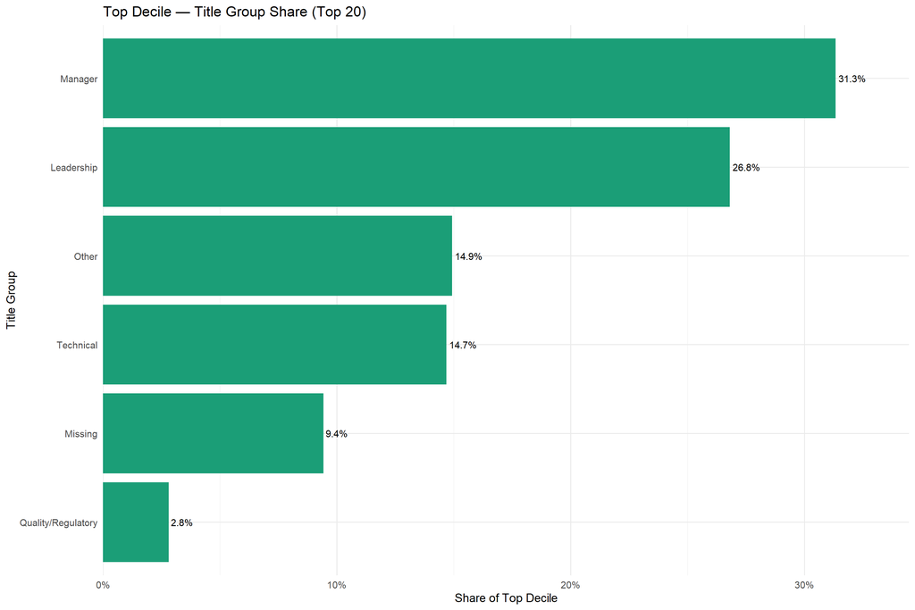

```r
top_decile_title %>%
  slice_head(n = 20) %>%   # top 20 title groups
  ggplot(aes(x = reorder(title_group, share),
             y = share)) +
  geom_col(fill = "#1B9E77") +
  geom_text(aes(label = scales::percent(share, accuracy = 0.1)),
            hjust = -0.1,
            size = 4) +
  coord_flip() +
  scale_y_continuous(labels = scales::percent,
                     expand = expansion(mult = c(0, 0.1))) +
  labs(
    title = "Top Decile — Title Group Share (Top 20)",
    x = "Title Group",
    y = "Share of Top Decile"
  ) +
  theme_minimal(base_size = 14)
```

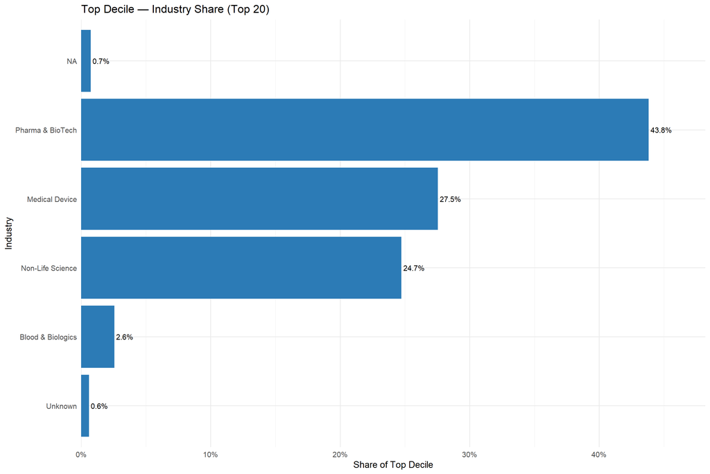

```r
library(ggplot2)

top_decile_industry %>%
  slice_head(n = 20) %>%   # top 20 industries
  ggplot(aes(x = reorder(acct_target_industry, share),
             y = share)) +
  geom_col(fill = "#2C7BB6") +
  geom_text(aes(label = scales::percent(share, accuracy = 0.1)),
            hjust = -0.1,
            size = 4) +
  coord_flip() +
  scale_y_continuous(labels = scales::percent,
                     expand = expansion(mult = c(0, 0.1))) +
  labs(
    title = "Top Decile — Industry Share (Top 20)",
    x = "Industry",
    y = "Share of Top Decile"
  ) +
  theme_minimal(base_size = 14)
```